# 颅骨骨髓 BCR：年轻与年老

- 显示所有代码
- 隐藏所有代码
- 查看源代码

供体层面的克隆型、同种型和体细胞突变分析

本版纳入年轻组 10 人（21–32 岁）和年老组 8 人（59–77 岁）。相对最初 21 人队列，去掉年老组 O6（LXY_SkullBM_240412）、O8（WLR220308_Z）和 O11（ZFR_SkullBM_240315）。短编号仍是 Y1–Y10、O1–O11，不重新编号。

本版看到的主要现象是：年老组浆细胞占 B 系细胞的比例更高，而且比保留 O8 时更清楚。浆细胞的扩增和 V 区突变仍然没有同样清楚的组间差异。IgG 浆细胞的扩增、突变和克隆分散程度也一并报告。记忆 B 细胞参与再次应答，浆细胞负责分泌抗体，所以这两类细胞放在前面。

每个点是一位供者，不是一个细胞。图上括号是这一项自己的原始 p；`age_tests.xlsx` 里的参考 BH 不要写成已经确认的年龄效应。细胞比例不是绝对数量。UMAP 仍用最初 21 人的坐标，只是不画 O6、O8 和 O11 的细胞。年轻组 4/10、年老组 8/8 来自动脉瘤相关手术，因此下面是这一队列的观察。数字见主要结论。

## 1 样本和细胞标签

这一节先确认比的是谁，以及图上的细胞名称是什么意思。年龄和分组只用颅骨骨髓。编号仍按最初 21 人的顺序，O6、O8 和 O11 不进入本版。保留年轻组 10 人（21–32 岁）、年老组 8 人（59–77 岁）。

细胞名称和图上的英文标签一致：

- Pro-B、Large Pre-B、Small Pre-B：骨髓里较早的 B 细胞前体。Large Pre-B 是其中正在增殖、并表达 VPREB1、IGLL1 的一群，不是 plasmablast。
- Immature B、Transitional B：已经形成但尚未成熟的 B 细胞。
- Naive B：成熟、尚未经历抗原反应的 B 细胞，通常带 IgM 或 IgD，V 区突变很少。
- Memory B：记忆 B 细胞，表达 CD27，可以出现抗体类别转换和 V 区突变。
- Plasma：浆细胞，表达 XBP1、PRDM1 和 SDC1，负责分泌抗体。
- CD3D+ T：混入的 T 细胞，后面的 B 细胞分析不包括它们。

**查看分析代码**

```r
sample_info <- read_csv(file.path(project_dir, "codes/sample_info.csv"), show_col_types = FALSE) %>%
  mutate(
    age_group = factor(age_group, levels = c("Young", "Old")),
    aneurysm = grepl("aneurysm|\\bMCA\\b|PICA|PComm", notes, ignore.case = TRUE)
  ) %>%
  arrange(age_group, sample_id) %>%
  group_by(age_group) %>%
  mutate(donor_label = paste0(if_else(as.character(age_group) == "Young", "Y", "O"), row_number())) %>%
  ungroup()
exclude_donor_labels <- c("O6", "O8", "O11")
sample_info_all <- sample_info %>%
  mutate(included = !donor_label %in% exclude_donor_labels)
sample_info <- sample_info_all %>% filter(included)
cluster_map <- read_csv(file.path(project_dir, "codes/cluster_lineage.csv"), show_col_types = FALSE) %>%
  mutate(
    cluster = as.character(cluster),
    cell_subtype = factor(cell_subtype, levels = names(subtype_col)),
    lineage = as.character(lineage)
  )
subtype_levels <- setdiff(names(subtype_col), "CD3D+ T")
main_subtypes <- c("Naive B", "Memory B", "Plasma")
stopifnot(
  !anyDuplicated(sample_info$sample_id),
  !anyDuplicated(cluster_map$cluster),
  all(c("0", "1", "2", "3", "4", "5", "6", "7", "8", "9", "10", "11") %in% cluster_map$cluster),
  !anyNA(sample_info$age_group)
)

design_table <- sample_info %>%
  count(age_group, aneurysm, sex, name = "n_donors")
write_xlsx(list(
  donors = sample_info,
  excluded = sample_info_all %>% filter(!included),
  design = design_table
), "study_design")
design_table
```

| age_group | aneurysm | sex | n_donors |
| --- | --- | --- | --- |
| Young | FALSE | F | 4 |
| Young | FALSE | M | 2 |
| Young | TRUE | F | 4 |
| Old | TRUE | F | 6 |
| Old | TRUE | M | 2 |

上表是本版纳入的供者。短编号仍是最初 21 人里的 Y1–Y10、O1–O11，因此没有 O6、O8 和 O11。被剔除的三位见 `study_design.xlsx` 的 excluded 表。

**查看分析代码**

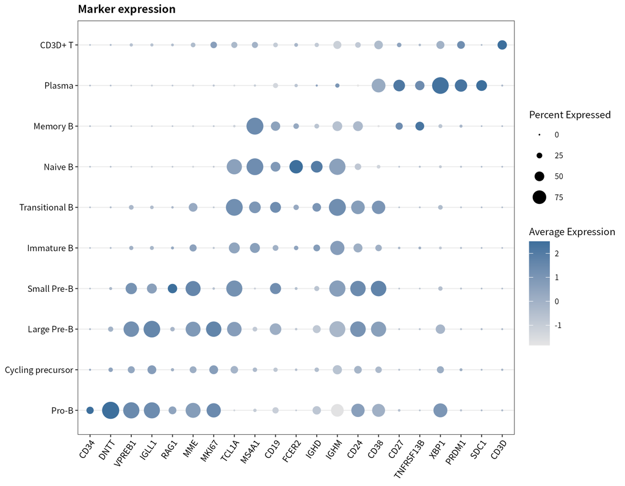

```r
obj <- readRDS(file.path(project_dir, "data/scRNA_harmony_luguB_quan.rds"))
obj$cluster <- as.character(obj$seurat_clusters)
obj$cell_subtype <- cluster_map$cell_subtype[match(obj$cluster, cluster_map$cluster)]
obj$lineage <- cluster_map$lineage[match(obj$cluster, cluster_map$cluster)]
obj$age_group <- sample_info_all$age_group[match(obj$sample_id, sample_info_all$sample_id)]
stopifnot(!anyNA(obj$cell_subtype), all(obj$sample_id %in% sample_info_all$sample_id))
full_emb <- as.data.frame(Embeddings(obj, "umap"))
colnames(full_emb)[1:2] <- c("UMAP_1", "UMAP_2")
umap_span <- max(diff(range(full_emb$UMAP_1)), diff(range(full_emb$UMAP_2))) * 1.12
umap_limits <- list(
  x = mean(range(full_emb$UMAP_1)) + c(-.5, .5) * umap_span,
  y = mean(range(full_emb$UMAP_2)) + c(-.5, .5) * umap_span
)
obj <- obj[, obj$sample_id %in% sample_info$sample_id]
stopifnot(all(obj$sample_id %in% sample_info$sample_id))

markers <- intersect(
  c("CD34", "DNTT", "VPREB1", "IGLL1", "RAG1", "MME", "MKI67", "TCL1A", "MS4A1",
    "CD19", "FCER2", "IGHD", "IGHM", "CD24", "CD38", "CD27", "TNFRSF13B",
    "XBP1", "PRDM1", "SDC1", "CD3D"),
  rownames(obj)
)
Idents(obj) <- factor(obj$cluster, levels = as.character(0:11))
p_dot <- DotPlot(obj, features = markers, group.by = "cell_subtype", cols = c("grey90", "#3D6F9C")) +
  theme_bcr(8) +
  theme(
    axis.text.x = element_text(angle = 55, hjust = 1, size = 7),
    axis.text.y = element_text(size = 7),
    legend.title = element_text(size = 8, colour = "black")
  ) +
  labs(x = NULL, y = NULL, title = "Marker expression",
    colour = "Scaled expression", size = "Cells expressing (%)")
save_plot(p_dot, "01_marker_dotplot", 7.2, 5.6)
print(p_dot)
```

图 01. 每个点对应一种细胞类型与一个基因。点的大小表示**表达该基因的细胞比例**；颜色表示标准化表达量（越深越高）。用它核对细胞命名：Naive B 应有 IGHD、IGHM 和 CD23，Memory B 应有 CD27，Plasma 应有 XBP1、PRDM1 和 SDC1。

**查看分析代码**

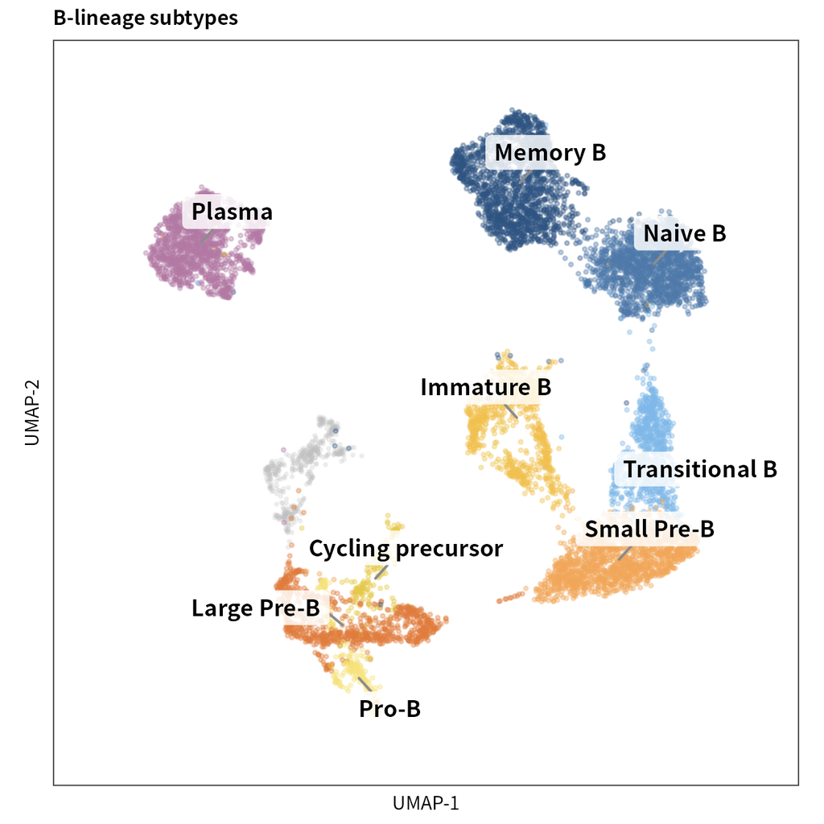

```r
emb <- as.data.frame(Embeddings(obj, "umap"))
colnames(emb)[1:2] <- c("UMAP_1", "UMAP_2")
emb$barcode <- rownames(Embeddings(obj, "umap"))
emb$cell_subtype <- obj$cell_subtype
emb$age_group <- obj$age_group
emb$lineage <- obj$lineage
emb$sample_id <- obj$sample_id
# Axis limits were fixed on the original 21-donor embedding before O6, O8 and O11 were removed.
label_xy <- emb %>%
  filter(lineage != "Non-B") %>%
  group_by(cell_subtype) %>%
  summarise(UMAP_1 = median(UMAP_1), UMAP_2 = median(UMAP_2), .groups = "drop")
p_umap <- ggplot(emb, aes(UMAP_1, UMAP_2, color = cell_subtype)) +
  geom_point(data = emb %>% filter(lineage == "Non-B"), color = "grey75", size = 0.35, alpha = 0.2) +
  geom_point(data = emb %>% filter(lineage != "Non-B"), size = 0.45, alpha = 0.35) +
  ggrepel::geom_label_repel(
    data = label_xy, aes(label = cell_subtype), color = "black", size = 3.2,
    family = bcr_font_family, fontface = "bold", seed = 1, max.overlaps = Inf,
    fill = scales::alpha("white", .82), label.size = 0, box.padding = .35,
    min.segment.length = .2, segment.color = "grey55", show.legend = FALSE
  ) +
  scale_color_manual(values = subtype_col, drop = FALSE) +
  coord_fixed(xlim = umap_limits$x, ylim = umap_limits$y) +
  theme_umap_ref() +
  guides(color = "none") +
  labs(title = "B-lineage subtypes", x = "UMAP-1", y = "UMAP-2")
save_plot(p_umap, "02_umap_subtype", 4.6, 4.6)
print(p_umap)
```

图 02. 每个点是一个细胞。距离近表示基因表达相似，不是实验测到的物理距离。颜色是上面的细胞类型，灰色是 CD3D+ T，后面不再使用。O6、O8 和 O11 的细胞已从图上去掉；坐标范围仍是原来 21 人那张 UMAP，没有重新计算位置。

## 2 重链选择

一个 B 细胞有时能测到不止一条重链。后面所有分析每个细胞只保留一条：能正常翻译、reads 最高的那条；reads 相同时再看 UMI 和 contig 编号。V 基因、J 基因、抗体类别和 CDR3 都来自这一条。

抗体类别由恒定区决定：IgM、IgD、IgG、IgA、IgE。测不到恒定区时就空着，不从别的基因名去猜，这些细胞不参加类别转换的统计。同一套 V(D)J 同时有 IgM 和 IgD 转录本时，只算一种重排。

**查看分析代码**

```r
contigs <- bind_rows(lapply(sample_info$sample_id, function(s) {
  path <- file.path(
    project_dir, "data/cell_ranger_multi", s, "outs/per_sample_outs", s,
    "vdj_b/filtered_contig_annotations.csv"
  )
  read_csv(
    path, show_col_types = FALSE,
    col_types = cols(.default = col_character(), reads = col_double(), umis = col_double())
  ) %>%
    mutate(sample_id = s, barcode = paste0(s, "_", barcode))
}))
selected <- select_bcr_chains(contigs)

meta <- obj@meta.data %>%
  tibble::rownames_to_column("barcode") %>%
  transmute(
    barcode,
    sample_id = as.character(sample_id),
    cluster = as.character(seurat_clusters)
  ) %>%
  left_join(cluster_map %>% select(cluster, cell_subtype, lineage), by = "cluster") %>%
  left_join(sample_info %>% select(sample_id, age_group, sex, age, aneurysm), by = "sample_id")

bcr <- selected %>%
  inner_join(meta %>% select(barcode, sample_id, cluster, cell_subtype, lineage, age_group, sex, age, aneurysm),
             by = c("barcode", "sample_id"))
stopifnot(
  !anyDuplicated(bcr$barcode),
  setequal(unique(obj$sample_id), sample_info$sample_id),
  all(bcr$contig_id %in% contigs$contig_id)
)

# Scope precedes counting: excluded Non-B cells must not enlarge B-cell clones.
analysis <- bcr %>% filter(lineage != "Non-B") %>% add_clone_fields()
flow <- tibble(
  step = c(
    "GEX cells in B subset", "Non-B working label", "B-lineage GEX cells",
    "Productive IGH, any cell in the subset", "B-lineage productive IGH",
    "Known constant gene", "Paired light chain", "Multiple productive IGH contigs",
    "Multiple distinct IGH rearrangements", "Ambiguous V gene"
  ),
  n = c(
    nrow(meta), sum(meta$lineage == "Non-B"), sum(meta$lineage != "Non-B"),
    nrow(bcr), nrow(analysis), sum(!is.na(analysis$c_gene)), sum(analysis$paired_light),
    sum(analysis$n_productive_igh > 1), sum(analysis$n_rearrangements > 1),
    sum(analysis$v_ambiguous)
  )
)
write_xlsx(list(flow = flow, donors = analysis %>% count(sample_id, age_group, name = "n_bcr")), "cell_flow")
flow
```

| step | n |
| --- | --- |
| GEX cells in B subset | 9866 |
| Non-B working label | 490 |
| B-lineage GEX cells | 9376 |
| Productive IGH, any cell in the subset | 7417 |
| B-lineage productive IGH | 7234 |
| Known constant gene | 7188 |
| Paired light chain | 5785 |
| Multiple productive IGH contigs | 71 |
| Multiple distinct IGH rearrangements | 71 |
| Ambiguous V gene | 0 |

最后进入分析的 B 系细胞有 7234 个，其中 IgD 199 个。上面的表是从全部细胞到这条重链的筛选计数，用来核对有没有在中途丢掉一大批细胞。

## 3 回收率

这一节看每个供者有多少 B 细胞真正测到了重链。柱高是百分比：有重链的 B 细胞，除以该供者全部 B 细胞。百分比高，只说明测到的比例高，不说明条数够做克隆比较。

克隆、多样性和突变要求至少 30 条重链。`MY_SkullBM_240304`（Y6）的柱子是 40%，但只有 16/40 条，所以不进入这些比较。其余供者都超过 145 条，全部保留。亚型比例用的是全部 B 细胞，这一位供者仍然保留。

**查看分析代码**

```r
whole <- meta %>%
  count(sample_id, name = "n_gex_all") %>%
  left_join(bcr %>% count(sample_id, name = "n_igh_all"), by = "sample_id") %>%
  mutate(scope = "whole subset, includes CD3D+ T", recovery = n_igh_all / n_gex_all)
b_den <- meta %>%
  filter(lineage != "Non-B") %>%
  count(sample_id, age_group, name = "n_gex_b") %>%
  left_join(analysis %>% count(sample_id, name = "n_igh_b"), by = "sample_id") %>%
  left_join(sample_info %>% select(sample_id, donor_label), by = "sample_id") %>%
  mutate(n_igh_b = replace_na(n_igh_b, 0L), recovery = n_igh_b / n_gex_b,
         include_library = n_igh_b >= min_bcr_cells,
         donor_label = factor(donor_label, levels = sample_info$donor_label),
         exclude_reason = if_else(include_library, "", paste0("fewer than ", min_bcr_cells, " heavy chains"))) %>%
  arrange(donor_label)
sub_den <- meta %>%
  filter(lineage != "Non-B") %>%
  count(sample_id, age_group, cell_subtype, name = "n_gex") %>%
  left_join(analysis %>% count(sample_id, cell_subtype, name = "n_igh"), by = c("sample_id", "cell_subtype")) %>%
  mutate(n_igh = replace_na(n_igh, 0L), recovery = n_igh / n_gex)
write_xlsx(list(whole_subset = whole, b_lineage = b_den, by_subtype = sub_den), "recovery")

p_rec <- b_den %>%
  mutate(library_status = if_else(include_library, "Eligible", "Excluded")) %>%
  ggplot(aes(donor_label, recovery * 100, fill = library_status)) +
  geom_col(width = 0.75) +
  scale_fill_manual(values = c(Eligible = "#4C78A8", Excluded = "#E45756"), name = NULL) +
  theme_bcr(8) +
  theme(axis.text.x = element_text(size = 7), legend.position = "bottom") +
  labs(x = NULL, y = "B cells with heavy chain (%)", title = "Heavy-chain recovery")
save_plot(p_rec, "03_b_lineage_recovery", 7.2, 3.6)
b_den %>% select(sample_id, age_group, n_gex_b, n_igh_b, recovery, include_library, exclude_reason)
```

| sample_id | age_group | n_gex_b | n_igh_b | recovery | include_library | exclude_reason |
| --- | --- | --- | --- | --- | --- | --- |
| CMY230607 | Young | 308 | 246 | 0.7987013 | TRUE |  |
| CZJ_230711 | Young | 303 | 243 | 0.8019802 | TRUE |  |
| JLX_SkullBM_240228 | Young | 287 | 238 | 0.8292683 | TRUE |  |
| MJ_SkullBM_240626 | Young | 1167 | 946 | 0.8106255 | TRUE |  |
| MYX_SkullBM_240711 | Young | 591 | 470 | 0.7952623 | TRUE |  |
| MY_SkullBM_240304 | Young | 40 | 16 | 0.4000000 | FALSE | fewer than 30 heavy chains |
| STX_SkullBM_240229 | Young | 470 | 386 | 0.8212766 | TRUE |  |
| WHH_BM231121 | Young | 475 | 389 | 0.8189474 | TRUE |  |
| ZM_SkullBM_240620 | Young | 1658 | 1379 | 0.8317250 | TRUE |  |
| ZYY_SkullBM_240226 | Young | 435 | 338 | 0.7770115 | TRUE |  |

[output cut: 8 more lines]

**查看分析代码**

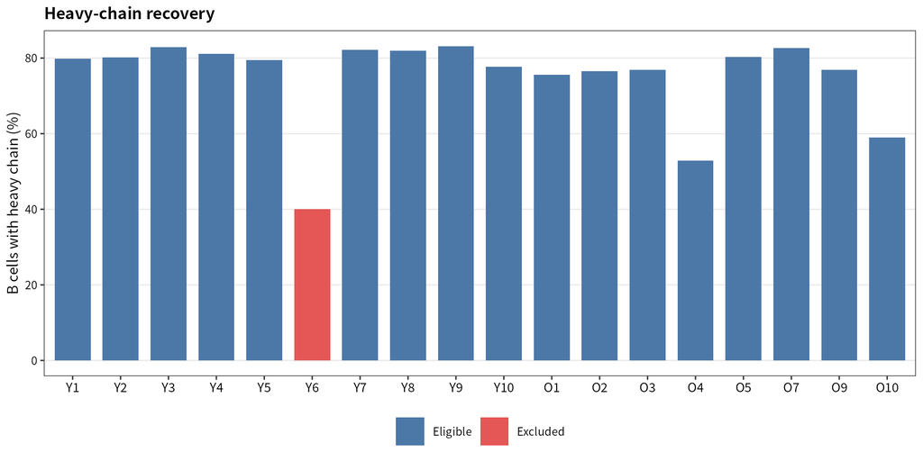

```r
print(p_rec)
```

图 03. 每根柱是一位供者。柱高是有重链的 B 细胞占该供者全部 B 细胞的百分比。Y6 的柱子是 40%，但表里只有 16 条重链，少于 30 条，所以不进入后面的克隆、多样性和突变比较。

## 4 亚型比例

这一节看每种 B 细胞占该供者 B 细胞的百分比，每个点或每根柱里的一份都是一位供者。

后面带括号的箱线图采用同一探索性规则：对年轻、年老两组供者数值分别做 Shapiro–Wilk（α = 0.05）；**仅当两组均未拒绝正态**时用 Welch t（比较供者**均值**），否则用 Wilcoxon。正文和表中报告的年轻→年老数字是供者**中位数**，用于描述分布，与 t 检验的目标量不同。小样本下 Shapiro 不显著只表示未检出偏离正态。图上括号为**原始 p**；导出表按 `family` 计算参考 BH。供者少于 3 的组不检验。原始 p < 0.05 记为**探索性信号**，不表述为确认的年龄效应或“不像偶然差别”。

**查看分析代码**

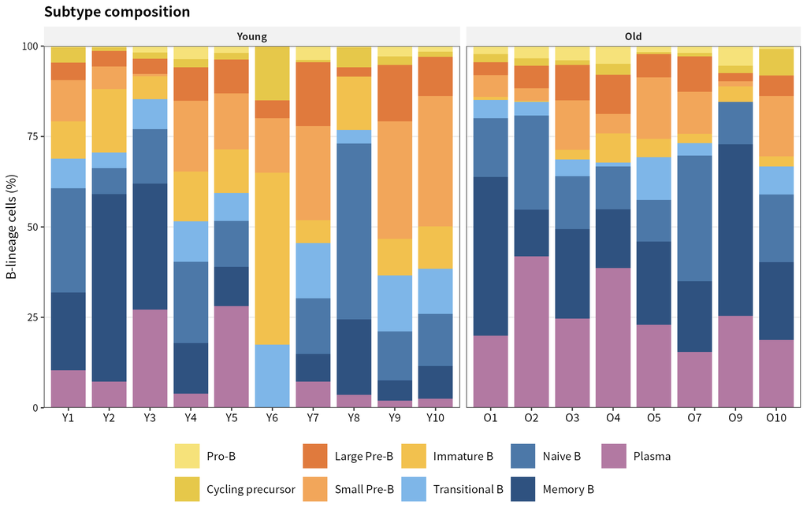

```r
stat_tests <- list()
b_meta <- meta %>% filter(lineage != "Non-B") %>% mutate(cell_subtype = as.character(cell_subtype))
subtype_grid <- tidyr::expand_grid(sample_id = unique(b_meta$sample_id), cell_subtype = subtype_levels) %>%
  left_join(b_meta %>% distinct(sample_id, age_group, sex, aneurysm), by = "sample_id") %>%
  left_join(b_meta %>% count(sample_id, cell_subtype, name = "n_cells"), by = c("sample_id", "cell_subtype")) %>%
  mutate(n_cells = replace_na(n_cells, 0L)) %>%
  group_by(sample_id) %>%
  mutate(fraction = n_cells / sum(n_cells)) %>%
  ungroup() %>%
  mutate(cell_subtype = factor(cell_subtype, levels = subtype_levels)) %>%
  left_join(sample_info %>% select(sample_id, donor_label), by = "sample_id") %>%
  mutate(donor_label = factor(donor_label, levels = sample_info$donor_label)) %>%
  arrange(donor_label, cell_subtype)

p_comp <- subtype_grid %>%
  ggplot(aes(donor_label, fraction * 100, fill = cell_subtype)) +
  geom_col(width = 0.85) +
  facet_grid(. ~ age_group, scales = "free_x", space = "free_x") +
  scale_fill_manual(values = subtype_col, drop = FALSE) +
  scale_y_continuous(expand = c(0, 0)) +
  coord_cartesian(ylim = c(0, 100)) +
  theme_bcr(8) +
  theme(axis.text.x = element_text(size = 7),
    legend.position = "bottom", legend.text = element_text(size = 7)) +
  guides(fill = guide_legend(nrow = 2)) +
  labs(x = NULL, y = "B-lineage cells (%)", title = "Subtype composition")
save_plot(p_comp, "04_subtype_composition", 7.2, 4.6)
print(p_comp)
```

**查看分析代码**

```r
for (st in subtype_levels) {
  stat_tests[[length(stat_tests) + 1]] <- wilcox_age(
    subtype_grid %>% filter(cell_subtype == st), "fraction",
    paste0("Subtype fraction, ", st), "abundance", min_donors
  )
}
merged <- subtype_grid %>%
  filter(cell_subtype %in% c("Immature B", "Transitional B")) %>%
  group_by(sample_id, age_group) %>%
  summarise(fraction = sum(fraction), .groups = "drop")
stat_tests[[length(stat_tests) + 1]] <- wilcox_age(
  merged, "fraction", "Subtype fraction, Immature B + Transitional B", "abundance_sensitivity", min_donors
)
```

图 04. 每位供者一根柱，颜色是细胞类型，加起来是 100%。这张图看整体组成，不做检验。

**查看分析代码**

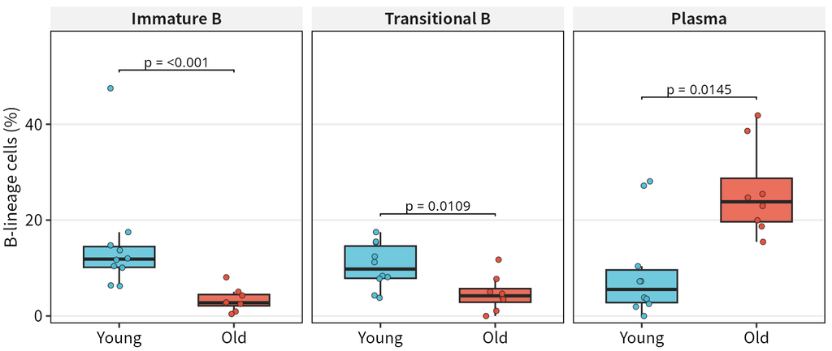

```r
fraction_main <- c("Immature B", "Transitional B", "Plasma")
fraction_rest <- setdiff(subtype_levels, fraction_main)
abundance_plot_tests <- collect_age_tests(stat_tests)
p_frac <- plot_age_box(
  subtype_grid %>% filter(cell_subtype %in% fraction_main),
  "fraction", "B-lineage cells (%)", NULL, "cell_subtype", percent = TRUE
)
p_frac <- annotate_age_plot(p_frac, subtype_grid %>% filter(cell_subtype %in% fraction_main), "fraction", abundance_plot_tests,
  tibble(cell_subtype = fraction_main, family = "abundance", metric = paste0("Subtype fraction, ", fraction_main)),
  facets = "cell_subtype")
p_frac_rest <- plot_age_box(
  subtype_grid %>% filter(cell_subtype %in% fraction_rest),
  "fraction", "B-lineage cells (%)", NULL, "cell_subtype", percent = TRUE
)
p_frac_rest <- annotate_age_plot(p_frac_rest, subtype_grid %>% filter(cell_subtype %in% fraction_rest), "fraction", abundance_plot_tests,
  tibble(cell_subtype = fraction_rest, family = "abundance", metric = paste0("Subtype fraction, ", fraction_rest)),
  facets = "cell_subtype")
save_plot(p_frac, "05_subtype_fraction_by_age", 5.2, 2.2)
print(p_frac)
```

**查看分析代码**

```r
abundance_bh <- adjust_tests(abundance_plot_tests %>% filter(family == "abundance"))
```

图 05. 每个点是一位供者，纵轴是该细胞类型占该供者 B 细胞的百分比。本分面含 Immature B、Transitional B 与 Plasma。 Immature B 年轻→年老供者中位数约 11.87%→2.76%（Wilcoxon；Young/Old n=10/8；图括号为原始 p = <0.001；同类检验参考 BH = 0.00776）。 Transitional B 年轻→年老供者中位数约 9.79%→4.21%（Welch t-test；Young/Old n=10/8；图括号为原始 p = 0.0109；同类检验参考 BH = 0.0436）。 Plasma 年轻→年老供者中位数约 5.55%→23.83%（Wilcoxon；Young/Old n=10/8；图括号为原始 p = 0.0145；同类检验参考 BH = 0.0436）。 浆细胞（Plasma）比例见本图；记忆 B（Memory B）比例见图 05s 与主要结论表。Immature 与 Transitional 分界并不绝对；合并 Immature+Transitional 的比较见 age_tests（family = abundance_sensitivity）。

**查看分析代码**

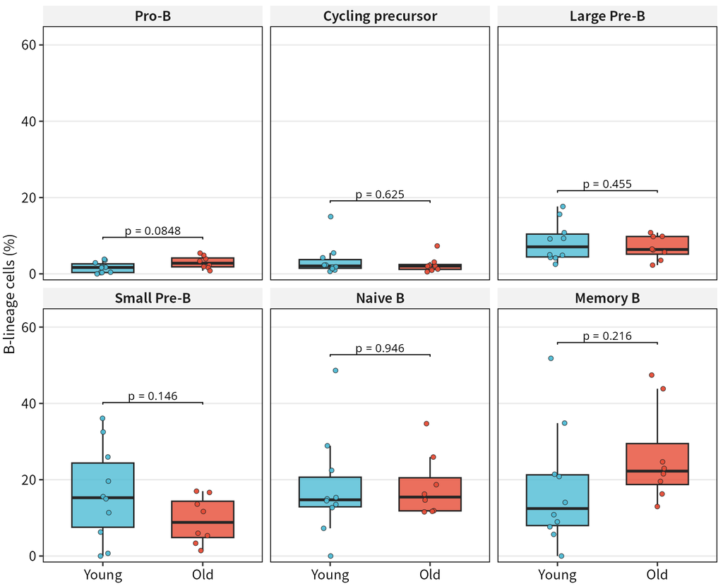

```r
save_plot(p_frac_rest, "05s_subtype_fraction_other", 5.3, 4.3)
print(p_frac_rest)
```

图 05s. 每个点是一位供者，纵轴为占该供者 B 系细胞的百分比；读法与图 05 相同（图括号为原始 p，同类检验参考 BH 见图注句式与 age_tests）。 Memory B 年轻→年老供者中位数约 12.44%→22.26%（Welch t-test；Young/Old n=10/8；图括号为原始 p = 0.216；同类检验参考 BH = 0.324）。 其余分面（Naive B、Pro-B 等）供描述性比较；浆细胞比例见图 05。

## 5 克隆

这一节只回答一件事：年老组里，属于扩增克隆的细胞是不是更多。

做法：克隆只在同一供者内部计算。IGHV 相同，并且重链 CDR3 氨基酸完全相同，算同一个克隆。不跨供者合并，也不做序列相似度聚类。一个克隆在当前统计范围内至少有 2 个细胞，其中的细胞就算扩增细胞。重链不足 30 条的供者不进入；某个亚型不足 10 个重链细胞的供者，不进入该亚型。

**查看分析代码**

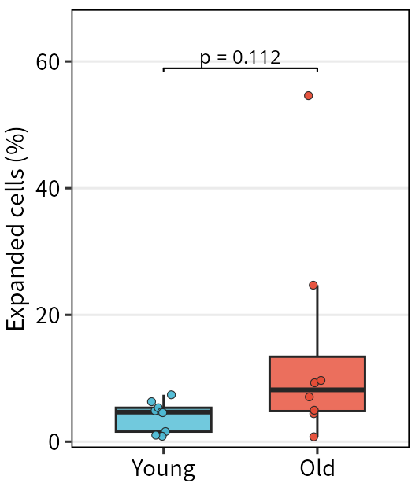

```r
library_donors <- b_den %>% filter(include_library) %>% pull(sample_id)
compartments <- list(
  `All B-lineage heavy chains` = analysis,
  `Naive + Memory + Plasma` = analysis %>% filter(cell_subtype %in% main_subtypes),
  `Naive B` = analysis %>% filter(cell_subtype == "Naive B"),
  `Memory B` = analysis %>% filter(cell_subtype == "Memory B"),
  `Plasma` = analysis %>% filter(cell_subtype == "Plasma")
)
definitions <- c(primary_ighv_cdr3aa = "clone_id", vj_cdr3nt = "clone_id_vj_nt", paired_vj_cdr3aa = "clone_id_paired")
clone_tables <- bind_rows(lapply(names(compartments), function(comp) {
  bind_rows(lapply(names(definitions), function(def) {
    donor_clone_metrics(compartments[[comp]], definitions[[def]]) %>%
      mutate(compartment = comp, definition = def)
  }))
}))
clone_tables <- bind_rows(clone_tables, bind_rows(lapply(names(compartments), function(comp) {
  donor_clone_metrics(compartments[[comp]] %>% filter(n_rearrangements == 1), "clone_id") %>%
    mutate(compartment = comp, definition = "primary_single_rearrangement")
})))
primary <- clone_tables %>% filter(definition == "primary_ighv_cdr3aa")
min_for <- function(comp) if (comp %in% c("All B-lineage heavy chains", "Naive + Memory + Plasma")) min_bcr_cells else min_subtype_cells
for (comp in names(compartments)) {
  one <- primary %>% filter(compartment == comp, n_bcr >= min_for(comp))
  for (metric in c("expanded_frac", "top10_frac", "shannon")) {
    stat_tests[[length(stat_tests) + 1]] <- wilcox_age(
      one, metric, paste(comp, "primary", metric, sep = "; "), "expansion", min_donors
    )
  }
}
for (comp in names(compartments)) {
  for (def in c("vj_cdr3nt", "paired_vj_cdr3aa", "primary_single_rearrangement")) {
    one <- clone_tables %>% filter(compartment == comp, definition == def, n_bcr >= min_for(comp))
    stat_tests[[length(stat_tests) + 1]] <- wilcox_age(
      one, "expanded_frac", paste(comp, def, "expanded_frac", sep = "; "),
      "clone_definition_sensitivity", min_donors
    )
  }
}

subtype_summary <- analysis %>%
  filter(!is.na(clone_id)) %>%
  group_by(sample_id, age_group, cell_subtype) %>%
  summarise(
    n_bcr = n(),
    expanded_frac = mean(expanded_within_subtype),
    shannon = shannon_div(subtype_clone_size[!duplicated(clone_id)]),
    .groups = "drop"
  ) %>%
  filter(n_bcr >= min_subtype_cells)
for (st in setdiff(subtype_levels, main_subtypes)) {
  stat_tests[[length(stat_tests) + 1]] <- wilcox_age(
    subtype_summary %>% filter(cell_subtype == st), "expanded_frac",
    paste0("Expanded fraction within ", st), "expansion", min_donors,
    test_id = paste("expansion", st, "within_subtype", "expanded_frac", sep = " | ")
  )
}
p_exp <- plot_age_box(
  primary %>% filter(compartment == "All B-lineage heavy chains", n_bcr >= min_bcr_cells),
  "expanded_frac", "Expanded cells (%)", NULL, percent = TRUE
)
clone_plot_tests <- collect_age_tests(stat_tests)
p_exp <- annotate_age_plot(p_exp,
  primary %>% filter(compartment == "All B-lineage heavy chains", n_bcr >= min_bcr_cells),
  "expanded_frac", clone_plot_tests,
  tibble(family = "expansion", metric = "All B-lineage heavy chains; primary; expanded_frac"))
save_plot(p_exp, "06_expanded_fraction_all", 1.85, 2.15)
print(p_exp)
```

图 06. 每个点是一位供者。纵轴是全部 B 系重链细胞中，扩增细胞占的百分比。结论：年轻和年老组没有明确差别。

**查看分析代码**

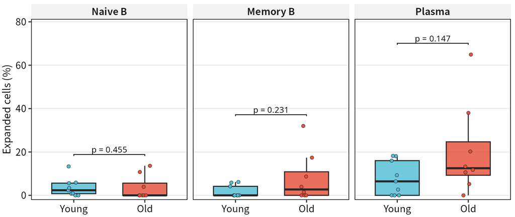

```r
subtype_test_map <- tibble(cell_subtype = subtype_levels, family = "expansion",
  metric = ifelse(subtype_levels %in% main_subtypes,
    paste(subtype_levels, "primary", "expanded_frac", sep = "; "),
    paste0("Expanded fraction within ", subtype_levels)))
p_exp_sub <- plot_age_box(
  subtype_summary %>% filter(cell_subtype %in% main_subtypes),
  "expanded_frac", "Expanded cells (%)", NULL, "cell_subtype", percent = TRUE
)
p_exp_sub <- annotate_age_plot(
  p_exp_sub, subtype_summary %>% filter(cell_subtype %in% main_subtypes),
  "expanded_frac", clone_plot_tests, subtype_test_map %>% filter(cell_subtype %in% main_subtypes),
  facets = "cell_subtype"
)
other_subtypes <- setdiff(subtype_levels, main_subtypes)
p_exp_rest <- plot_age_box(
  subtype_summary %>% filter(cell_subtype %in% other_subtypes),
  "expanded_frac", "Expanded cells (%)", NULL, "cell_subtype", percent = TRUE
)
p_exp_rest <- annotate_age_plot(
  p_exp_rest, subtype_summary %>% filter(cell_subtype %in% other_subtypes),
  "expanded_frac", clone_plot_tests, subtype_test_map %>% filter(cell_subtype %in% other_subtypes),
  facets = "cell_subtype"
)
save_plot(p_exp_sub, "07_expanded_fraction_by_subtype", 5.2, 2.2)
print(p_exp_sub)
```

图 07. 每个点仍是一位供者，但分母和克隆大小都只在该亚型内部计算。例如一个克隆有 1 个 Memory B 和 1 个 Plasma，这个 Memory B 细胞在本图里不算扩增。Memory B 的供者中位数是 0.00% 对 2.72%（p = 0.231）。Plasma 是 6.45% 对 12.52%（p = 0.147）。这三项都没有 p < 0.05，还不能说扩增更强。这张图不是后面的 STARTRAC。

**查看分析代码**

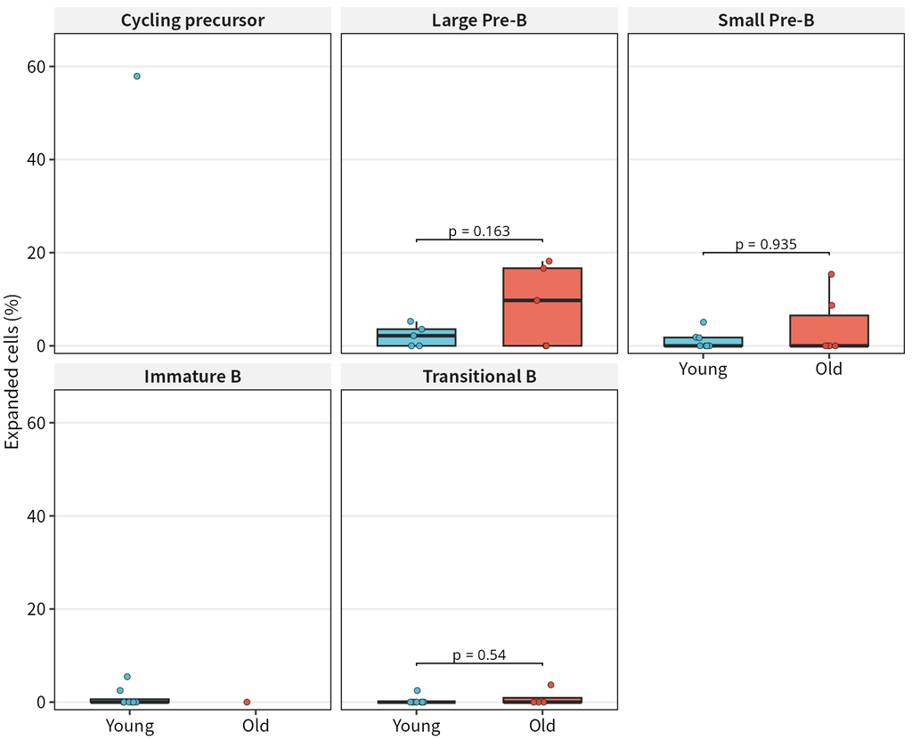

```r
save_plot(p_exp_rest, "07s_expanded_other_subtypes", 5.3, 4.3)
print(p_exp_rest)
```

**查看分析代码**

```r
write_xlsx(list(by_definition = clone_tables, by_subtype = subtype_summary), "clone_metrics")
```

图 07s. 其余亚型的亚型内扩增比例，读法和图 07 相同。供者太少的分面只有点，没有检验。

下面四张图不再做组间检验，只展示克隆大小的构成。克隆大小按同一供者内的细胞数分成 =1、=2 和 >2。

**查看分析代码**

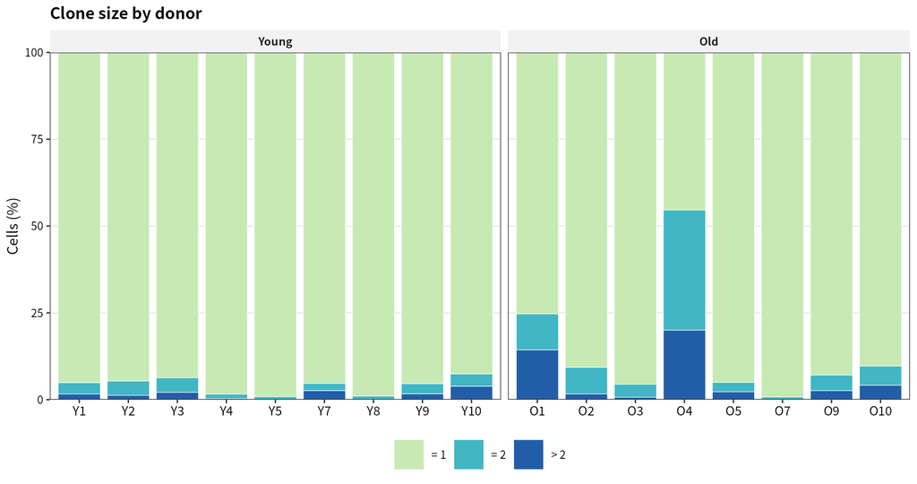

```r
sized <- analysis %>%
  filter(!is.na(clone_size), sample_id %in% library_donors) %>%
  mutate(clone_bin = clone_size_bin(clone_size))
donor_bins <- sized %>%
  count(sample_id, age_group, clone_bin, name = "n") %>%
  complete(nesting(sample_id, age_group), clone_bin = factor(clone_bin_levels, levels = clone_bin_levels), fill = list(n = 0)) %>%
  group_by(sample_id, age_group) %>%
  mutate(pct = exact_percent(n)) %>%
  ungroup() %>%
  left_join(sample_info %>% select(sample_id, donor_label), by = "sample_id")
donor_bins <- donor_bins %>%
  mutate(donor_label = factor(donor_label, levels = sample_info$donor_label)) %>%
  arrange(donor_label, clone_bin)
stopifnot(all(abs(tapply(donor_bins$pct, donor_bins$sample_id, sum) - 100) < 1e-8))
p_donor_bins <- ggplot(donor_bins, aes(donor_label, pct, fill = clone_bin)) +
  geom_col(width = 0.86, color = "white", linewidth = 0.15) +
  facet_grid(~ age_group, scales = "free_x", space = "free_x") +
  scale_fill_manual(values = clone_bin_col, name = "Clone size") +
  scale_y_continuous(expand = c(0, 0)) +
  coord_cartesian(ylim = c(0, 100)) +
  labs(x = NULL, y = "Cells (%)", title = "Clone size by donor") +
  theme_bcr(8) +
  theme(axis.text.x = element_text(size = 7),
    legend.position = "bottom", panel.grid.major.x = element_blank())
save_plot(p_donor_bins, "18_clone_size_by_donor", 7.2, 3.8)
print(p_donor_bins)
```

**查看分析代码**

```r
write_fig_xlsx("18_clone_size_by_donor", donor_bins, NULL,
  tibble(field = c("sample_id", "donor_label", "clone_bin", "n", "pct"),
    meaning = c("供者", "图中短编号，对照 study_design", "全库克隆大小档", "细胞数", "该供者内百分比，三档合计 100")),
  tibble(item = "clone size", value = "repertoire clone_size: =1, =2, >2"))
```

图 18. 每位合格供者一根柱，三种颜色分别是克隆大小 =1、=2、>2 的细胞比例，加起来是 100%。横轴是供者短编号。多数细胞落在 =1，也就是没有扩增。

**查看分析代码**

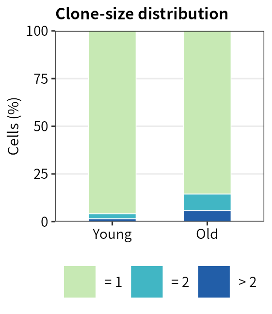

```r
homeostasis <- donor_bins %>%
  group_by(age_group, clone_bin) %>%
  summarise(pct = mean(pct), .groups = "drop")
p_homeostasis <- ggplot(homeostasis, aes(age_group, pct, fill = clone_bin)) +
  geom_col(width = 0.5, color = "white", linewidth = 0.2) +
  scale_fill_manual(values = clone_bin_col, name = NULL) +
  scale_y_continuous(expand = c(0, 0)) +
  coord_cartesian(ylim = c(0, 100)) +
  labs(x = NULL, y = "Cells (%)", title = "Clone-size distribution") +
  theme_bcr(8) +
  theme(legend.position = "bottom", legend.text = element_text(size = 7),
    panel.grid.major.x = element_blank(),
    axis.text = element_text(size = 7), axis.title = element_text(size = 7.5),
    plot.title = element_text(size = 8, face = "bold"))
save_plot(p_homeostasis, "19_clone_homeostasis", 1.95, 2.25)
print(p_homeostasis)
```

**查看分析代码**

```r
write_fig_xlsx("19_clone_homeostasis", homeostasis, NULL,
  tibble(field = c("age_group", "clone_bin", "pct"),
    meaning = c("年龄组", "全库克隆大小档", "供者等权平均百分比")),
  tibble(item = "weighting", value = "each eligible donor contributes equally"))
write_xlsx(list(by_donor = donor_bins, age_mean = homeostasis), "clone_size_bins")
```

图 19. 把图 18 里同一年龄组的供者比例取平均，每位供者权重相同。两组的构成接近，年老组并没有变成以大克隆为主。

**查看分析代码**

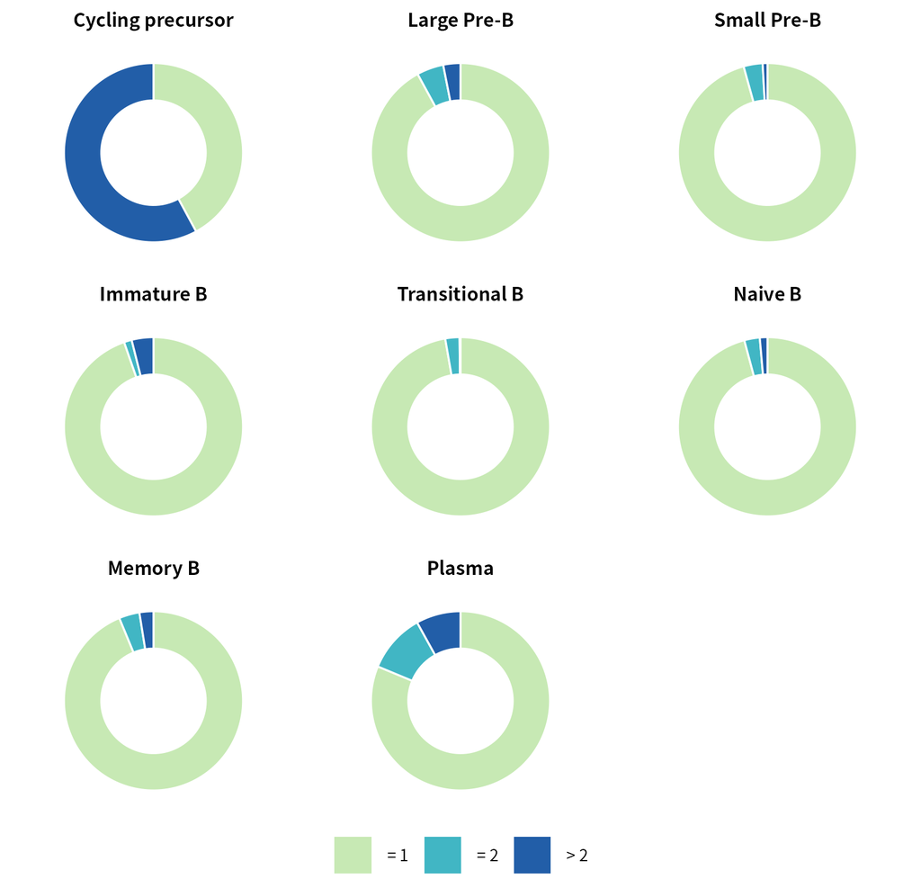

```r
subtype_bins <- sized %>%
  count(sample_id, cell_subtype, clone_bin, name = "n") %>%
  group_by(sample_id, cell_subtype) %>%
  mutate(n_cells = sum(n)) %>%
  ungroup() %>%
  complete(nesting(sample_id, cell_subtype, n_cells),
    clone_bin = factor(clone_bin_levels, levels = clone_bin_levels), fill = list(n = 0)) %>%
  filter(n_cells >= min_subtype_cells) %>%
  group_by(sample_id, cell_subtype) %>%
  mutate(pct = 100 * n / sum(n)) %>%
  ungroup() %>%
  group_by(cell_subtype, clone_bin) %>%
  summarise(fraction = mean(pct) / 100, .groups = "drop")
donut_panels <- lapply(subtype_levels, function(st) {
  make_donut(subtype_bins %>% filter(cell_subtype == st), "clone_bin", st, clone_bin_col)
})
donut_panels <- donut_panels[!vapply(donut_panels, is.null, logical(1))]
bin_legend <- cowplot::get_plot_component(
  ggplot(data.frame(clone_bin = factor(clone_bin_levels, levels = clone_bin_levels), y = 1),
    aes(clone_bin, y, fill = clone_bin)) +
    geom_col() + scale_fill_manual(values = clone_bin_col, name = "Clone size") +
    theme(legend.position = "bottom", legend.text = element_text(size = 7)),
  "^guide-box-bottom$")
p_size_donuts <- plot_grid(plotlist = donut_panels, ncol = 3)
p_size_donuts <- plot_grid(p_size_donuts, bin_legend, ncol = 1, rel_heights = c(1, 0.08)) +
  theme(plot.background = element_rect(fill = "white", colour = NA))
save_plot(p_size_donuts, "20_clone_size_donuts", 5.5, 5.3)
print(p_size_donuts)
```

**查看分析代码**

```r
write_fig_xlsx("20_clone_size_donuts", subtype_bins, NULL,
  tibble(field = c("cell_subtype", "clone_bin", "fraction"),
    meaning = c("亚型", "全库克隆大小，不是亚型内重算的大小", "达到细胞数阈值的供者的平均比例")),
  tibble(item = c("clone size scope", "min_subtype_cells"),
    value = c("repertoire clone_size grouped by subtype", min_subtype_cells)))
```

**查看分析代码**

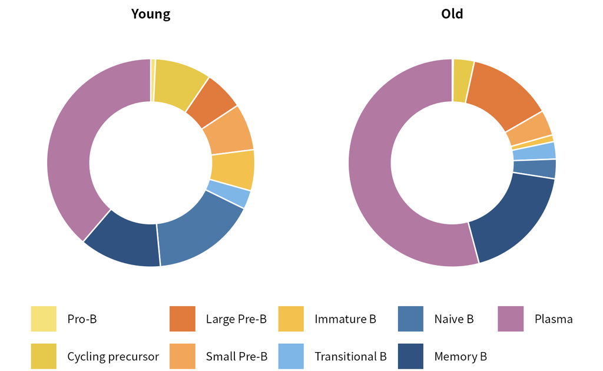

```r
expanded_mix <- analysis %>%
  filter(!is.na(clone_size), clone_size >= 2, sample_id %in% library_donors) %>%
  count(sample_id, age_group, cell_subtype, name = "n") %>%
  group_by(sample_id, age_group) %>%
  mutate(n_expanded = sum(n)) %>%
  ungroup() %>%
  complete(nesting(sample_id, age_group, n_expanded),
    cell_subtype = factor(subtype_levels, levels = subtype_levels), fill = list(n = 0)) %>%
  group_by(sample_id, age_group) %>%
  mutate(fraction = n / sum(n)) %>%
  ungroup() %>%
  group_by(age_group, cell_subtype) %>%
  summarise(fraction = mean(fraction), .groups = "drop")
expanded_donuts <- lapply(c("Young", "Old"), function(g) {
  make_donut(expanded_mix %>% filter(age_group == g), "cell_subtype", g, subtype_col)
})
subtype_legend <- cowplot::get_plot_component(
  ggplot(data.frame(cell_subtype = factor(subtype_levels, levels = subtype_levels), y = 1),
    aes(cell_subtype, y, fill = cell_subtype)) +
    geom_col() + scale_fill_manual(values = subtype_col, name = NULL) +
    theme(legend.position = "bottom", legend.text = element_text(size = 7)) +
    guides(fill = guide_legend(nrow = 2)),
  "^guide-box-bottom$")
p_expanded_donuts <- plot_grid(plotlist = expanded_donuts, ncol = 2)
p_expanded_donuts <- plot_grid(p_expanded_donuts, subtype_legend, ncol = 1, rel_heights = c(1, 0.22)) +
  theme(plot.background = element_rect(fill = "white", colour = NA))
save_plot(p_expanded_donuts, "21_expanded_subtype_donuts", 5.2, 3.2)
print(p_expanded_donuts)
```

**查看分析代码**

```r
write_fig_xlsx("21_expanded_subtype_donuts", expanded_mix, NULL,
  tibble(field = c("age_group", "cell_subtype", "fraction"),
    meaning = c("年龄组", "亚型", "先在有扩增细胞的供者内算占比，再组内平均")),
  tibble(item = "denominator", value = "cells with repertoire clone_size >= 2"))
write_xlsx(list(subtype_clone_size = subtype_bins, expanded_by_subtype = expanded_mix), "clone_composition_donuts")
```

图 21. 只保留克隆大小至少为 2 的细胞，看它们落在哪些亚型。左右两个环是年轻组和年老组：先在每位有扩增细胞的供者内算亚型占比，再对供者取平均。这张图描述扩增细胞来自哪些亚型，不做年龄检验。

## 6 克隆多样性

这一节用和图 06 相同的克隆，看克隆有多分散，不看扩增细胞百分比。Gini–Simpson 的范围是 0 到 1，不是 Inverse Simpson。Inverse Simpson 是有效克隆数，没有 1 这个上限。

**查看分析代码**

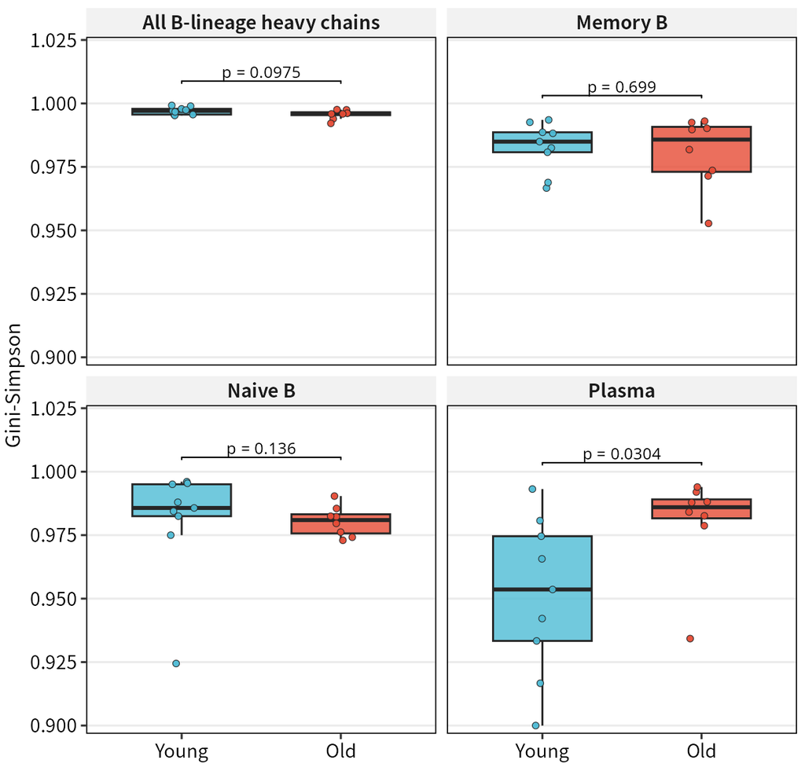

```r
diversity_sets <- c("All B-lineage heavy chains", "Naive B", "Memory B", "Plasma")
diversity_donor <- bind_rows(lapply(diversity_sets, function(comp) {
  cells <- if (comp == "All B-lineage heavy chains") analysis else analysis %>% filter(cell_subtype == comp)
  cells %>%
    filter(!is.na(clone_id), sample_id %in% library_donors) %>%
    group_by(sample_id, age_group) %>%
    summarise(n_bcr = n(), gini = gini_simpson(clone_id), .groups = "drop") %>%
    mutate(compartment = comp)
}))
for (comp in diversity_sets) {
  one <- diversity_donor %>% filter(compartment == comp, n_bcr >= min_for(comp))
  stat_tests[[length(stat_tests) + 1]] <- wilcox_age(
    one, "gini", paste0("Gini-Simpson, ", comp), "diversity", min_donors
  )
}
gini_plot <- diversity_donor %>%
  filter(n_bcr >= ifelse(compartment == "All B-lineage heavy chains", min_bcr_cells, min_subtype_cells))
p_gini <- plot_age_box(gini_plot, "gini", "Gini-Simpson", NULL, "compartment")
p_gini <- annotate_age_plot(
  p_gini, gini_plot,
  "gini", collect_age_tests(stat_tests),
  tibble(compartment = diversity_sets, family = "diversity", metric = paste0("Gini-Simpson, ", diversity_sets)),
  facets = "compartment"
)
save_plot(p_gini, "22_gini_simpson", 4.2, 4.0)
print(p_gini)
```

**查看分析代码**

```r
write_fig_xlsx("22_gini", gini_plot, statistics_from_plot(p_gini),
  tibble(field = c("sample_id", "compartment", "n_bcr", "gini"),
    meaning = c("供者", "比较范围", "纳入的重链细胞数", "Gini-Simpson，1 为完全分散")),
  tibble(item = c("min_bcr_cells", "min_subtype_cells"), value = c(min_bcr_cells, min_subtype_cells)))
write_xlsx(diversity_donor, "diversity")
```

图 22. 每个点是一位供者，纵轴是 Gini–Simpson（`1 - sum(p²)`，基于该供者克隆频率 (p)）。越接近 1，克隆越分散；若 (N) 个细胞各属不同克隆，指数为 `1 - 1/N`。Memory B 未见一致组间差异；Plasma 的点须结合该供者回收的浆细胞数解读（进入比较的供者，可定义克隆的浆细胞数中位数年轻约 31、年老约 91）。看扩增比例请用图 06、图 07。

## 7 亚型内扩增和亚型间转换

这一节是 STARTRAC，和前面的扩增细胞百分比不是同一个量。某个亚型里少于 10 个能定义克隆的细胞时，该供者不进入。年龄比较仍以图 06 和图 07 为准。

**查看分析代码**

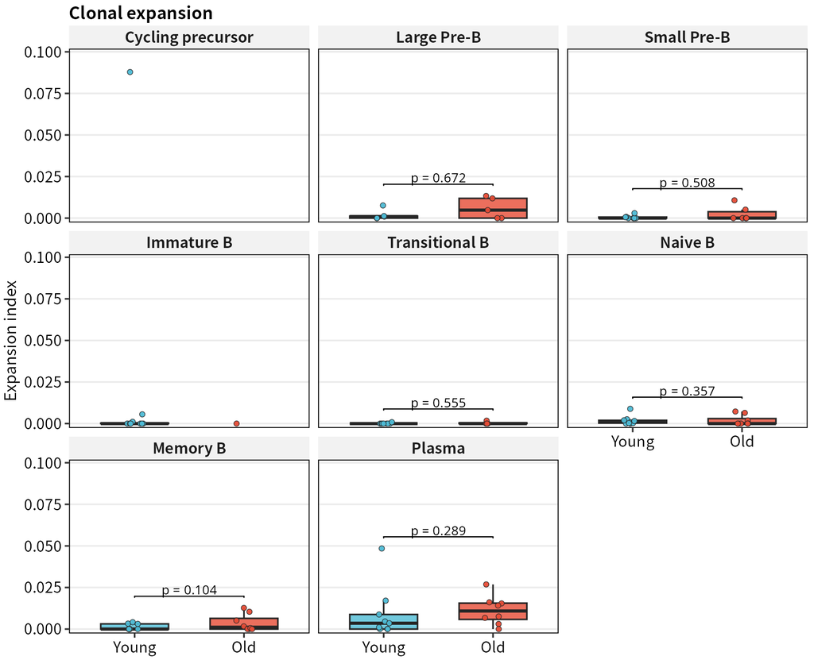

```r
startrac_donor <- bind_rows(lapply(split(analysis, analysis$sample_id), function(s) {
  counted <- s %>% filter(!is.na(clone_id)) %>% count(cell_subtype, name = "n_cells")
  idx <- startrac_indices(s$clone_id, s$cell_subtype)
  if (!nrow(idx)) return(NULL)
  idx %>%
    mutate(sample_id = s$sample_id[1], age_group = s$age_group[1]) %>%
    left_join(counted, by = "cell_subtype") %>%
    filter(!is.na(n_cells), n_cells >= min_subtype_cells)
}))
startrac_donor <- startrac_donor %>%
  mutate(cell_subtype = factor(cell_subtype, levels = subtype_levels)) %>%
  filter(sample_id %in% library_donors)
for (st in intersect(subtype_levels, unique(as.character(startrac_donor$cell_subtype)))) {
  one <- startrac_donor %>% filter(cell_subtype == st)
  stat_tests[[length(stat_tests) + 1]] <- wilcox_age(
    one, "expa", paste0("STARTRAC expansion, ", st), "startrac_expa", min_donors
  )
  stat_tests[[length(stat_tests) + 1]] <- wilcox_age(
    one, "tran", paste0("STARTRAC transition, ", st), "startrac_tran", min_donors
  )
}
star_levels <- intersect(subtype_levels, unique(as.character(startrac_donor$cell_subtype)))
p_expa <- plot_age_box(startrac_donor, "expa", "Expansion index", "Clonal expansion", "cell_subtype")
p_expa <- annotate_age_plot(
  p_expa, startrac_donor, "expa", collect_age_tests(stat_tests),
  tibble(cell_subtype = star_levels, family = "startrac_expa",
    metric = paste0("STARTRAC expansion, ", star_levels)),
  facets = "cell_subtype"
)
save_plot(p_expa, "23_startrac_expansion", 5.3, 4.3)
print(p_expa)
```

图 23. 每个点是一位供者，纵轴是 STARTRAC 的 expansion。它看细胞是不是集中在少数克隆上，不是扩增细胞的百分比。Memory B 的供者中位数是 0.00000 对 0.00110（p = 0.104）。差值很小，不能当成扩增增强。

**查看分析代码**

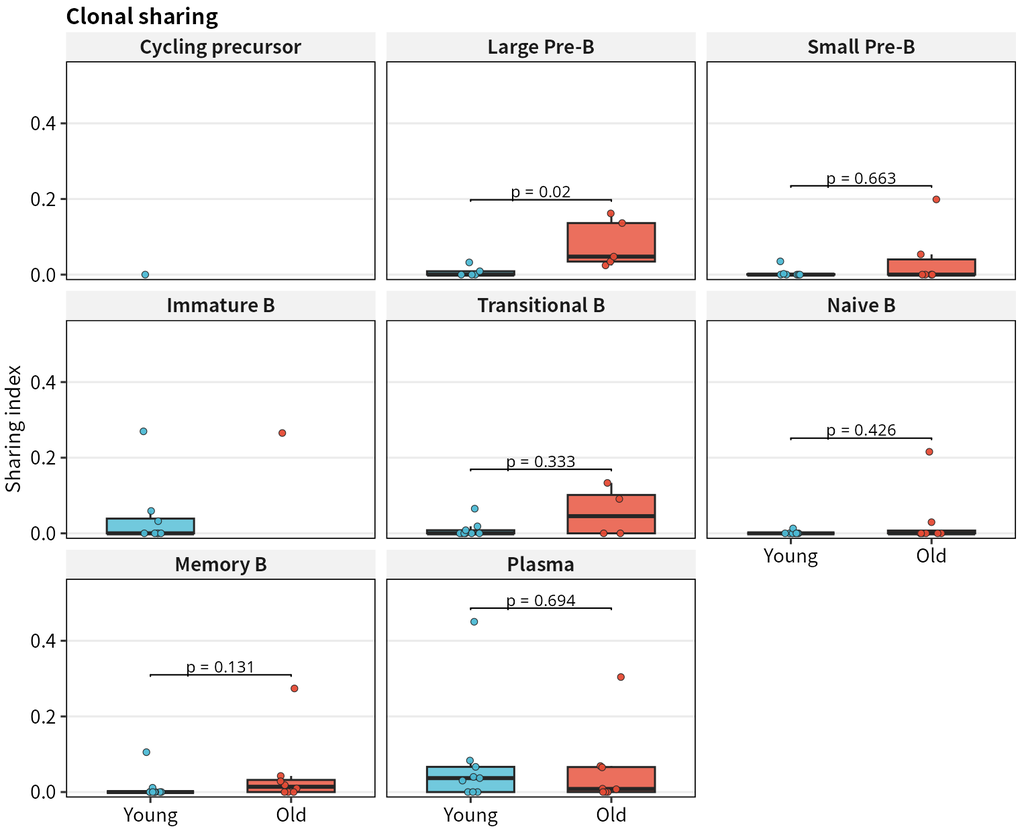

```r
p_tran <- plot_age_box(startrac_donor, "tran", "Sharing index", "Clonal sharing", "cell_subtype")
p_tran <- annotate_age_plot(
  p_tran, startrac_donor, "tran", collect_age_tests(stat_tests),
  tibble(cell_subtype = star_levels, family = "startrac_tran",
    metric = paste0("STARTRAC transition, ", star_levels)),
  facets = "cell_subtype"
)
save_plot(p_tran, "23_startrac_transition", 5.3, 4.3)
print(p_tran)
```

**查看分析代码**

```r
write_fig_xlsx("23_startrac_expansion", startrac_donor, statistics_from_plot(p_expa),
  tibble(field = c("sample_id", "cell_subtype", "expa", "tran", "n_cells"),
    meaning = c("供者", "亚型", "STARTRAC 扩增指数", "STARTRAC 转换指数，表示亚型间共享", "该亚型中能定义克隆的细胞数")),
  tibble(item = "min_subtype_cells", value = min_subtype_cells))
write_fig_xlsx("23_startrac_transition", startrac_donor, statistics_from_plot(p_tran),
  tibble(field = c("sample_id", "cell_subtype", "expa", "tran", "n_cells"),
    meaning = c("供者", "亚型", "STARTRAC 扩增指数", "亚型间克隆共享指数", "该亚型中能定义克隆的细胞数")),
  tibble(item = "min_subtype_cells", value = min_subtype_cells))
write_xlsx(startrac_donor, "startrac")
```

图 24. 每个点是一位供者，纵轴是同一个克隆是否出现在不同细胞类型里。它不表示转换方向，也不作为年龄结论。

## 8 同种型

这一节看抗体类别。class-switched 只包括 IgG、IgA 和 IgE。IgM 和 IgD 不算转换。分母是恒定区已知的细胞。

**查看分析代码**

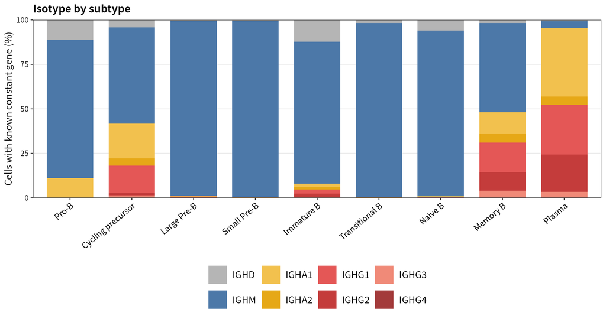

```r
known <- analysis %>% filter(!is.na(isotype_group))
iso_donor <- known %>%
  count(sample_id, age_group, isotype_group, name = "n") %>%
  group_by(sample_id) %>%
  mutate(fraction = n / sum(n), n_known = sum(n)) %>%
  ungroup()
iso_unknown <- analysis %>% count(sample_id, name = "n_bcr") %>%
  left_join(known %>% count(sample_id, name = "n_known"), by = "sample_id") %>%
  mutate(n_known = replace_na(n_known, 0L), n_unknown = n_bcr - n_known)
use_donors <- b_den %>% filter(include_library) %>% select(sample_id, age_group)
use_donors <- use_donors %>%
  inner_join(iso_unknown %>% filter(n_known >= min_bcr_cells) %>% select(sample_id), by = "sample_id")
for (iso in c("IGHM", "IGHD", "IGHA", "IGHG")) {
  one <- use_donors %>%
    left_join(iso_donor %>% filter(isotype_group == iso) %>% select(sample_id, fraction), by = "sample_id") %>%
    mutate(fraction = replace_na(fraction, 0))
  stat_tests[[length(stat_tests) + 1]] <- wilcox_age(
    one, "fraction", paste0(iso, " fraction, all B-lineage heavy chains"), "isotype", min_donors
  )
}
switched_donor <- known %>%
  group_by(sample_id, age_group) %>%
  summarise(switched_frac = mean(switched), n_known = n(), .groups = "drop") %>%
  filter(sample_id %in% use_donors$sample_id)
stat_tests[[length(stat_tests) + 1]] <- wilcox_age(
  switched_donor, "switched_frac", "Class-switched fraction, all B-lineage heavy chains", "isotype", min_donors
)

iso_sub <- known %>%
  group_by(sample_id, age_group, cell_subtype) %>%
  summarise(
    n_known = n(),
    switched_frac = mean(switched),
    ighm_frac = mean(isotype_group == "IGHM"),
    ighg_frac = mean(isotype_group == "IGHG"),
    igha_frac = mean(isotype_group == "IGHA"),
    .groups = "drop"
  ) %>%
  filter(n_known >= min_subtype_cells)
for (st in c(main_subtypes, "Immature B", "Transitional B")) {
  one <- iso_sub %>% filter(cell_subtype == st)
  for (metric in c("switched_frac", "ighm_frac", "ighg_frac", "igha_frac")) {
    stat_tests[[length(stat_tests) + 1]] <- wilcox_age(
      one, metric, paste(metric, st, sep = ", "), "isotype", min_donors
    )
  }
}
iso_exp <- known %>%
  filter(!is.na(expanded_within_isotype)) %>%
  group_by(sample_id, age_group, isotype_group) %>%
  summarise(
    n_known = n(),
    expanded_within_isotype = mean(expanded_within_isotype),
    in_repertoire_expanded_clone = mean(expanded_repertoire),
    .groups = "drop"
  ) %>%
  filter(n_known >= min_subtype_cells, sample_id %in% library_donors)
for (iso in c("IGHM", "IGHA", "IGHG")) {
  stat_tests[[length(stat_tests) + 1]] <- wilcox_age(
    iso_exp %>% filter(isotype_group == iso), "expanded_within_isotype",
    paste0("Within-isotype expanded fraction, ", iso), "isotype", min_donors
  )
}

p_iso <- known %>%
  count(cell_subtype, isotype, name = "n") %>%
  group_by(cell_subtype) %>%
  mutate(fraction = 100 * n / sum(n)) %>%
  ggplot(aes(cell_subtype, fraction, fill = isotype)) +
  geom_col(width = 0.75) +
  scale_fill_manual(values = isotype_col) +
  scale_y_continuous(expand = c(0, 0)) +
  coord_cartesian(ylim = c(0, 100)) +
  theme_bcr(8) +
  theme(axis.text.x = element_text(angle = 40, hjust = 1, size = 7),
    legend.position = "bottom", legend.text = element_text(size = 8)) +
  labs(x = NULL, y = "Cells with known constant gene (%)", title = "Isotype by subtype")
save_plot(p_iso, "08_isotype_by_subtype", 7.2, 3.8)
print(p_iso)
```

**查看分析代码**

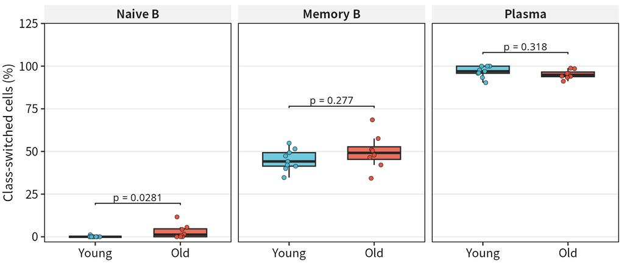

```r
p_sw <- plot_age_box(
  iso_sub %>% filter(cell_subtype %in% main_subtypes),
  "switched_frac", "Class-switched cells (%)", NULL, "cell_subtype", percent = TRUE
)
p_sw <- annotate_age_plot(p_sw, iso_sub %>% filter(cell_subtype %in% main_subtypes),
  "switched_frac", collect_age_tests(stat_tests),
  tibble(cell_subtype = main_subtypes, family = "isotype", metric = paste0("switched_frac, ", main_subtypes)),
  facets = "cell_subtype")
save_plot(p_sw, "09_switched_by_main_subtype", 5.2, 2.2)
print(p_sw)
```

图 09. 每个点是一位供者，纵轴是该亚型里 class-switched 细胞的百分比。Naive B 的原始 p = 0.028。这不能解释成 Naive B 在做类别转换：本版全部 Naive B 里只有 8 个 IgG 和 5 个 IgA，更像是少量已转换细胞落在 Naive B 聚类里。Memory B 的原始 p = 0.277，Plasma 的原始 p = 0.318，这两处没有明确年龄差异。

## 9 V 基因

这一节看 B 细胞使用哪些 V 基因，是不是年老组偏向某几个基因。每个供者先计算一个 V 基因占该供者重链的百分比，没有测到的基因记为 0，再比较年轻和年老。图上只画平均使用率最高的 15 个基因，每个点是一位供者。

按细胞计数时，IGHV4-59 在年老组更高。改成每个克隆只算一票后，方向相同，但 p 值更大。再放到 Naive B、Memory B 和 Plasma 里面分别比较，没有看到稳定的年龄差异。所以它只是一个全库层面的线索，不能说某种细胞的 V 基因使用发生了改变。

**查看分析代码**

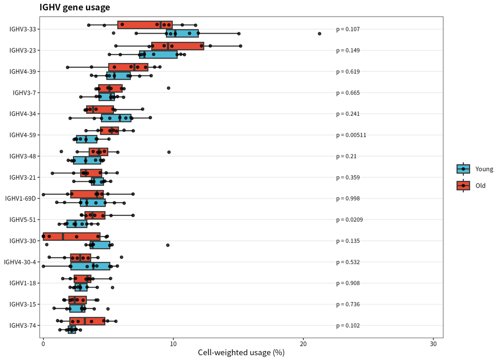

```r
v_cells <- analysis %>% filter(!v_ambiguous, sample_id %in% library_donors)
v_cell <- v_usage_grid(v_cells, library_donors, weight = "cell") %>%
  left_join(sample_info %>% select(sample_id, age_group), by = "sample_id")
v_clone <- v_usage_grid(v_cells, library_donors, weight = "clone") %>%
  left_join(sample_info %>% select(sample_id, age_group), by = "sample_id")
v_mean <- v_cell %>% group_by(v_gene) %>% summarise(mean_pct = mean(pct), .groups = "drop") %>% arrange(desc(mean_pct))
test_genes <- v_mean %>% filter(mean_pct >= 1) %>% pull(v_gene)
for (gene in test_genes) {
  stat_tests[[length(stat_tests) + 1]] <- wilcox_age(
    v_cell %>% filter(v_gene == gene), "pct", paste0("Cell-weighted IGHV, ", gene), "v_gene_cell", min_donors
  )
  stat_tests[[length(stat_tests) + 1]] <- wilcox_age(
    v_clone %>% filter(v_gene == gene), "pct", paste0("Clone-weighted IGHV, ", gene), "v_gene_clone", min_donors
  )
}
# Genes with a cell-weighted signal are checked inside Naive, Memory and Plasma
# so a shift in subtype mix is not reported as a repertoire-wide V-gene change.
v_signal <- bind_rows(stat_tests) %>%
  filter(family == "v_gene_cell", !is.na(p_value), p_value < 0.05) %>%
  pull(metric) %>%
  sub("^Cell-weighted IGHV, ", "", .)
for (gene in v_signal) {
  for (st in main_subtypes) {
    donors <- analysis %>%
      filter(cell_subtype == st, !v_ambiguous, sample_id %in% library_donors) %>%
      count(sample_id, age_group, name = "n_cells") %>%
      filter(n_cells >= min_subtype_cells)
    one <- donors %>%
      left_join(
        analysis %>% filter(cell_subtype == st, v_gene == gene) %>% count(sample_id, name = "n_gene"),
        by = "sample_id"
      ) %>%
      mutate(n_gene = replace_na(n_gene, 0L), pct = 100 * n_gene / n_cells)
    stat_tests[[length(stat_tests) + 1]] <- wilcox_age(
      one, "pct", paste0("Cell-weighted IGHV within ", st, ", ", gene),
      "v_gene_within_subtype", min_donors
    )
  }
}
top_v <- head(v_mean$v_gene, 15)
p_v <- v_cell %>%
  filter(v_gene %in% top_v) %>%
  mutate(v_gene = factor(v_gene, levels = rev(top_v))) %>%
  ggplot(aes(v_gene, pct, fill = age_group)) +
  geom_boxplot(outlier.shape = NA, width = 0.7, position = position_dodge(0.8)) +
  geom_point(position = position_jitterdodge(jitter.width = 0.1, dodge.width = 0.8), size = 1, alpha = 0.75) +
  scale_fill_manual(values = age_col) +
  coord_flip() + theme_bcr(8) +
  labs(x = NULL, y = "Cell-weighted usage (%)", title = "IGHV gene usage")
v_annotation <- tibble(v_gene = factor(top_v, levels = rev(top_v)), family = "v_gene_cell",
  metric = paste0("Cell-weighted IGHV, ", top_v)) %>%
  left_join(collect_age_tests(stat_tests), by = c("family", "metric"))
stopifnot(!anyNA(v_annotation$test_id))
v_annotation$annotation_label <- format_exact_p(v_annotation$p_value)
vmax <- max(v_cell$pct[v_cell$v_gene %in% top_v])
v_annotation$annotation_y <- vmax * 1.06
p_v <- p_v + geom_text(data = v_annotation, aes(x = v_gene, y = annotation_y, label = annotation_label),
  inherit.aes = FALSE, hjust = 0, size = 2.1, family = bcr_font_family, lineheight = 1) +
  scale_y_continuous(limits = c(0, vmax * 1.42), expand = expansion(mult = c(.01, .02))) +
  labs(title = "IGHV gene usage")
attr(p_v, "bcr_stat_annotations") <- v_annotation
save_plot(p_v, "10_ighv_usage", 7.2, 5.2)
print(p_v)
```

**查看分析代码**

```r
write_xlsx(list(cell_weighted = v_cell, clone_weighted = v_clone), "ighv_usage")
```

## 10 体细胞高频突变

相对未重排的种系 V 区参考，SHM 报告为 IGHV 区碱基差异比例（%）。图上每一位供者先在该亚型内取细胞突变率的中位数，再作组间比较。它描述序列变化，不代表抗体亲和力或分泌量。突变百分比来自所选重链的 IGHV 区（IMGT V 区、种系比对），不算 CDR3，也不是整条重链；对不上所选重链的细胞不进入。

IgD 也参与突变计算，但细胞数很少，下面在算出突变率之后再给出计数。多数供者的 Memory B 只有 1–2 个 IgD，达不到每供者 10 个细胞，所以没有单独的 IgD 图。分同种型的图只保留 IgM、IgG 和 IgA。

**查看分析代码**

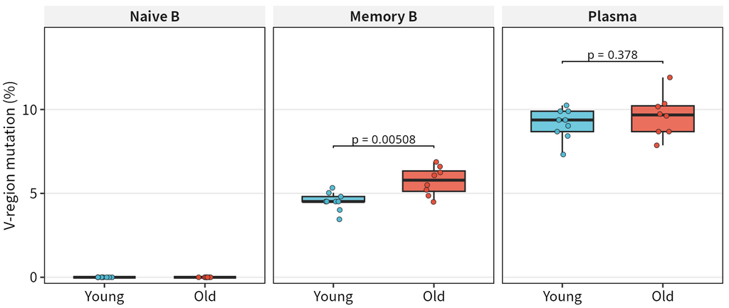

```r
pass_files <- file.path(shm_cache_dir, sample_info$sample_id, "shm_result_db-pass.tsv")
names(pass_files) <- sample_info$sample_id
if (any(!file.exists(pass_files))) stop("SHM cache is missing:\n", paste(pass_files[!file.exists(pass_files)], collapse = "\n"))
shm_manifest <- tibble(
  sample_id = names(pass_files),
  path = pass_files,
  bytes = file.info(pass_files)$size,
  md5 = unname(tools::md5sum(pass_files))
)
write_xlsx(shm_manifest, "shm_cache_manifest")

db <- bind_rows(lapply(names(pass_files), function(s) {
  read_tsv(pass_files[[s]], show_col_types = FALSE) %>%
    mutate(sample_id = s, sequence_id = as.character(sequence_id))
}))
db <- db %>% filter(locus == "IGH", productive_flag(productive))
shm_hit <- db %>%
  inner_join(
    analysis %>% transmute(sample_id, barcode, contig_id, cdr3_nt),
    by = c("sample_id", "sequence_id" = "contig_id")
  ) %>%
  mutate(
    cdr3_match = junction_10x == cdr3_nt,
    alignment_ok = !is.na(sequence_alignment) & !is.na(germline_alignment) &
      nchar(sequence_alignment) > 0 & nchar(sequence_alignment) == nchar(germline_alignment)
  )
shm_use <- shm_hit %>%
  filter(cdr3_match, alignment_ok) %>%
  group_by(barcode) %>%
  slice(1) %>%
  ungroup()
shm_mut <- observedMutations(
  shm_use,
  sequenceColumn = "sequence_alignment",
  germlineColumn = "germline_alignment",
  regionDefinition = IMGT_V,
  frequency = TRUE,
  combine = TRUE,
  nproc = 4
)
shm_mut <- shm_mut %>%
  transmute(
    barcode, contig_id = sequence_id,
    mu_percent = 100 * as.numeric(mu_freq),
    v_identity = as.numeric(v_identity),
    callable_v_bases = mapply(function(a, g) {
      aa <- strsplit(substr(a, 1, 312), "", fixed = TRUE)[[1]]
      gg <- strsplit(substr(g, 1, 312), "", fixed = TRUE)[[1]]
      sum(aa %in% c("A", "C", "G", "T") & gg %in% c("A", "C", "G", "T"))
    }, sequence_alignment, germline_alignment)
  )
analysis <- analysis %>%
  left_join(shm_mut %>% select(barcode, mu_percent, v_identity, callable_v_bases), by = "barcode") %>%
  mutate(shm_reason = case_when(
    !is.na(mu_percent) ~ "IMGT_V from selected contig",
    barcode %in% shm_hit$barcode[!shm_hit$cdr3_match] ~ "selected contig CDR3 did not match MakeDb",
    barcode %in% shm_hit$barcode[!shm_hit$alignment_ok] ~ "selected contig alignment failed",
    TRUE ~ "selected contig absent from MakeDb pass"
  ))
flow <- bind_rows(flow, tibble(
  step = c(
    "Orphon V name retained",
    "Valid IMGT V SHM on selected contig",
    "Selected contig absent from MakeDb",
    "Selected contig CDR3 disagreed with MakeDb",
    "Selected contig alignment failed"
  ),
  n = c(
    sum(analysis$v_orphon, na.rm = TRUE),
    sum(analysis$shm_reason == "IMGT_V from selected contig"),
    sum(analysis$shm_reason == "selected contig absent from MakeDb pass"),
    sum(analysis$shm_reason == "selected contig CDR3 did not match MakeDb"),
    sum(analysis$shm_reason == "selected contig alignment failed")
  )
))
write_xlsx(list(flow = flow, donors = analysis %>% count(sample_id, age_group, name = "n_bcr")), "cell_flow")

shm_cell <- analysis %>%
  filter(!is.na(mu_percent)) %>%
  group_by(sample_id, age_group, cell_subtype) %>%
  summarise(n_shm = n(), median_mu = median(mu_percent), .groups = "drop") %>%
  filter(n_shm >= min_subtype_cells)
shm_clone <- analysis %>%
  filter(!is.na(mu_percent), !is.na(clone_id)) %>%
  group_by(sample_id, age_group, cell_subtype, clone_id) %>%
  summarise(clone_mu = median(mu_percent), .groups = "drop") %>%
  group_by(sample_id, age_group, cell_subtype) %>%
  summarise(n_clones = n(), median_clone_mu = median(clone_mu), .groups = "drop") %>%
  filter(n_clones >= min_subtype_cells)
for (st in subtype_levels) {
  stat_tests[[length(stat_tests) + 1]] <- wilcox_age(
    shm_cell %>% filter(cell_subtype == st), "median_mu",
    paste0("Cell-median SHM, ", st), "shm_cell", min_donors
  )
  stat_tests[[length(stat_tests) + 1]] <- wilcox_age(
    shm_clone %>% filter(cell_subtype == st), "median_clone_mu",
    paste0("Clone-median SHM, ", st), "shm_clone", min_donors
  )
}
memory_iso <- analysis %>%
  filter(cell_subtype == "Memory B", !is.na(mu_percent), !is.na(isotype_group)) %>%
  group_by(sample_id, age_group, isotype_group) %>%
  summarise(n_shm = n(), median_mu = median(mu_percent), .groups = "drop") %>%
  filter(n_shm >= min_subtype_cells)
plasma_iso <- analysis %>%
  filter(cell_subtype == "Plasma", !is.na(mu_percent), !is.na(isotype_group)) %>%
  group_by(sample_id, age_group, isotype_group) %>%
  summarise(n_shm = n(), median_mu = median(mu_percent), .groups = "drop") %>%
  filter(n_shm >= min_subtype_cells)
for (iso in c("IGHM", "IGHG", "IGHA")) {
  stat_tests[[length(stat_tests) + 1]] <- wilcox_age(
    memory_iso %>% filter(isotype_group == iso), "median_mu",
    paste0("Memory SHM within ", iso), "shm_memory_isotype", min_donors
  )
  stat_tests[[length(stat_tests) + 1]] <- wilcox_age(
    plasma_iso %>% filter(isotype_group == iso), "median_mu",
    paste0("Plasma SHM within ", iso), "shm_plasma_isotype", min_donors
  )
}
p_shm <- plot_age_box(
  shm_cell %>% filter(cell_subtype %in% main_subtypes),
  "median_mu", "V-region mutation (%)", NULL, "cell_subtype"
)
shm_plot_tests <- collect_age_tests(stat_tests)
p_shm <- annotate_age_plot(p_shm, shm_cell %>% filter(cell_subtype %in% main_subtypes), "median_mu",
  shm_plot_tests, tibble(cell_subtype = main_subtypes, family = "shm_cell",
    metric = paste0("Cell-median SHM, ", main_subtypes)), facets = "cell_subtype")
save_plot(p_shm, "11_shm_main_subtypes", 5.2, 2.2)
print(p_shm)
```

本版重链里 IgD 共 199 个，其中能算出 V 区突变率的有 199 个。Memory B 的 IgD 有 24 个。这些细胞的突变中位数是 0。

图 11. 每个点是一位供者，纵轴是该亚型细胞的 IGHV 区突变中位数。括号是本版原始 p。Naive B 通常接近 0。Plasma 的组间差异以括号和主要结论表为准。

**查看分析代码**

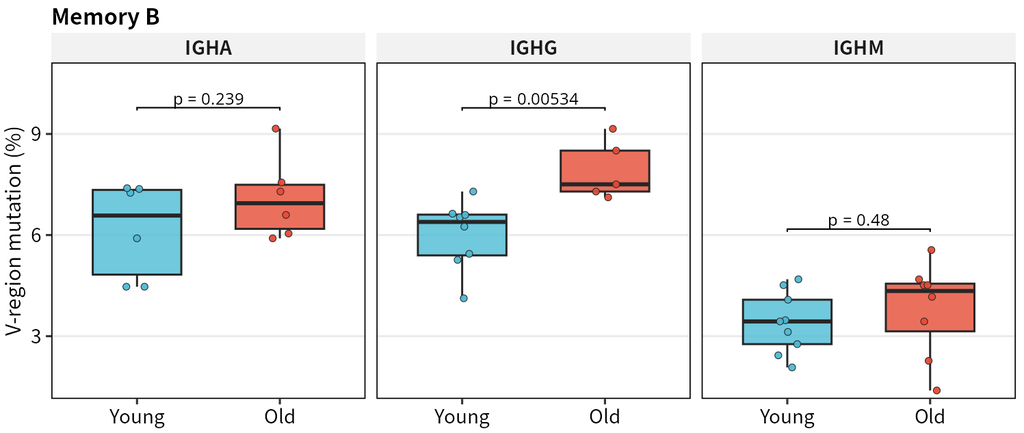

```r
p_mem <- plot_age_box(
  memory_iso %>% filter(isotype_group %in% c("IGHM", "IGHG", "IGHA")),
  "median_mu", "V-region mutation (%)", "Memory B", "isotype_group"
)
p_mem <- annotate_age_plot(p_mem, memory_iso %>% filter(isotype_group %in% c("IGHM", "IGHG", "IGHA")),
  "median_mu", shm_plot_tests, tibble(isotype_group = c("IGHM", "IGHG", "IGHA"),
    family = "shm_memory_isotype", metric = paste0("Memory SHM within ", c("IGHM", "IGHG", "IGHA"))),
  facets = "isotype_group")
save_plot(p_mem, "12_shm_memory_by_isotype", 5.2, 2.2)
print(p_mem)
```

**查看分析代码**

```r
write_xlsx(list(
  cell = shm_cell, clone = shm_clone, memory_isotype = memory_iso, plasma_isotype = plasma_iso,
  high = analysis %>% filter(!is.na(mu_percent)) %>% slice_max(mu_percent, n = 30, with_ties = FALSE) %>%
    select(barcode, sample_id, cell_subtype, contig_id, v_gene, c_gene, cdr3_aa, mu_percent, callable_v_bases)
), "shm")
```

图 12. 只看 Memory B，再按 IgM、IgG、IgA 分开。括号是本版原始 p。IgG 记忆 B 的供者中位数和 p 见主要结论表。

## 11 IgG 浆细胞

浆细胞分泌的抗体不都是同一类。这一节只留抗体类型为 IgG 的浆细胞，看三件和前面 Memory B 相同的事：有没有克隆扩增、V 区突变得高不高、克隆是分散还是挤在少数序列上。每位供者先在自己的 IgG 浆细胞里汇总成一个数，再比较年轻组和年老组。IgG 浆细胞少于 10 个的供者不进入检验。突变描述的是序列和种系 V 区差多少，不是抗体结合得紧不紧，也不是分泌量。

**查看分析代码**

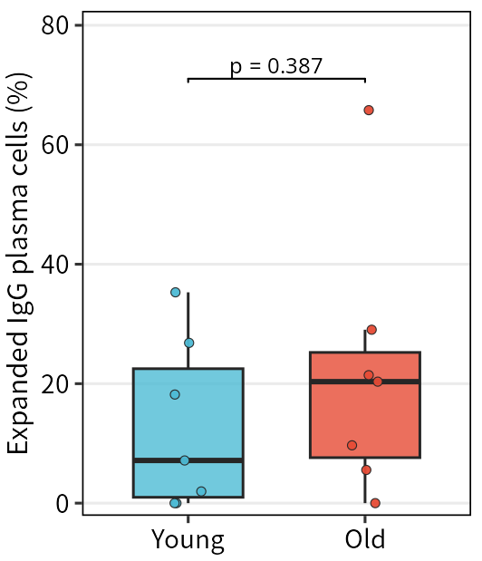

```r
igg_plasma <- analysis %>%
  filter(cell_subtype == "Plasma", isotype_group == "IGHG", !is.na(clone_id))
igg_plasma_metrics <- donor_clone_metrics(igg_plasma, "clone_id") %>%
  filter(n_bcr >= min_subtype_cells) %>%
  mutate(gini = purrr::map_dbl(sample_id, function(s) {
    gini_simpson(igg_plasma$clone_id[igg_plasma$sample_id == s])
  }))
for (metric in c("expanded_frac", "top10_frac", "shannon")) {
  stat_tests[[length(stat_tests) + 1]] <- wilcox_age(
    igg_plasma_metrics, metric, paste("IGHG Plasma", metric, sep = "; "), "igg_plasma", min_donors
  )
}
stat_tests[[length(stat_tests) + 1]] <- wilcox_age(
  igg_plasma_metrics, "gini", "Gini-Simpson, IGHG Plasma", "igg_plasma", min_donors
)
plasma_b <- analysis %>%
  filter(cell_subtype == "Plasma") %>%
  count(sample_id, age_group, name = "n_plasma")
igg_among <- plasma_b %>%
  left_join(igg_plasma %>% count(sample_id, name = "n_igg"), by = "sample_id") %>%
  mutate(n_igg = replace_na(n_igg, 0L), igg_frac = n_igg / n_plasma) %>%
  filter(n_plasma >= min_subtype_cells)
stat_tests[[length(stat_tests) + 1]] <- wilcox_age(
  igg_among, "igg_frac", "IGHG fraction within Plasma", "igg_plasma", min_donors
)
p_igg_exp <- plot_age_box(igg_plasma_metrics, "expanded_frac", "Expanded IgG plasma cells (%)", NULL, percent = TRUE)
igg_tests <- collect_age_tests(stat_tests)
p_igg_exp <- annotate_age_plot(
  p_igg_exp, igg_plasma_metrics, "expanded_frac", igg_tests,
  tibble(family = "igg_plasma", metric = "IGHG Plasma; expanded_frac")
)
save_plot(p_igg_exp, "25_igg_plasma_expanded", 1.85, 2.15)
print(p_igg_exp)
```

**查看分析代码**

```r
write_fig_xlsx("25_igg_plasma_expanded", igg_plasma_metrics, statistics_from_plot(p_igg_exp),
  tibble(field = c("sample_id", "n_bcr", "expanded_frac", "shannon", "gini"),
    meaning = c("供者", "IgG 浆细胞数", "扩增细胞比例", "Shannon", "Gini-Simpson")),
  tibble(item = "min_subtype_cells", value = min_subtype_cells))
```

图 25. 每个点是一位供者。纵轴是 IgG 浆细胞里，属于扩增克隆的细胞占百分之几。同一个供者里，IGHV 相同而且重链 CDR3 氨基酸完全相同、至少有 2 个细胞，才算扩增。只在 IgG 浆细胞内部计算，不把别的浆细胞算进来。年轻组中位数是 7.14%，年老组是 20.34%（7 对 7 位供者，p = 0.387）。两组重叠很大，还不能说扩增更强。

**查看分析代码**

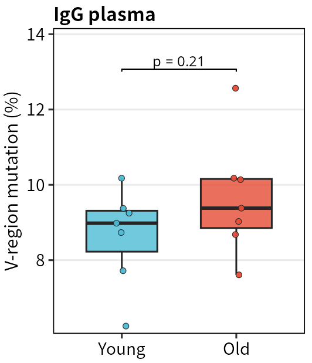

```r
p_igg_shm <- plot_age_box(
  plasma_iso %>% filter(isotype_group == "IGHG"),
  "median_mu", "V-region mutation (%)", "IgG plasma"
)
p_igg_shm <- annotate_age_plot(
  p_igg_shm, plasma_iso %>% filter(isotype_group == "IGHG"), "median_mu", shm_plot_tests,
  tibble(family = "shm_plasma_isotype", metric = "Plasma SHM within IGHG")
)
save_plot(p_igg_shm, "26_igg_plasma_shm", 1.85, 2.15)
print(p_igg_shm)
```

**查看分析代码**

```r
write_fig_xlsx("26_igg_plasma_shm", p_igg_shm$data, statistics_from_plot(p_igg_shm),
  tibble(field = c("sample_id", "n_shm", "median_mu"),
    meaning = c("供者", "有突变率的 IgG 浆细胞数", "供者内突变率中位数")),
  tibble(item = "min_subtype_cells", value = min_subtype_cells))
```

图 26. 每个点是一位供者。纵轴是这位供者 IgG 浆细胞的 V 区突变中位数。算法和图 12 里 IgG Memory B 相同：先算每个细胞相对种系 V 区的差异，再取该供者的中位数。图 17 中间的 IgG 一格是同一批数字。两组都在 9% 左右（约 9.0% 对 9.4%，p = 0.21），没有明确差别。

**查看分析代码**

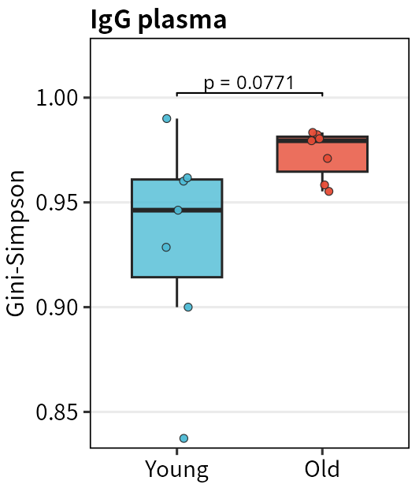

```r
p_igg_gini <- plot_age_box(igg_plasma_metrics, "gini", "Gini-Simpson", "IgG plasma")
p_igg_gini <- annotate_age_plot(
  p_igg_gini, igg_plasma_metrics, "gini", igg_tests,
  tibble(family = "igg_plasma", metric = "Gini-Simpson, IGHG Plasma")
)
save_plot(p_igg_gini, "27_igg_plasma_gini", 1.85, 2.15)
print(p_igg_gini)
```

**查看分析代码**

```r
write_fig_xlsx("27_igg_plasma_gini", igg_plasma_metrics, statistics_from_plot(p_igg_gini),
  tibble(field = c("sample_id", "n_bcr", "gini"),
    meaning = c("供者", "IgG 浆细胞数", "Gini-Simpson，越接近 1 越分散")),
  tibble(item = "min_subtype_cells", value = min_subtype_cells))
write_xlsx(list(metrics = igg_plasma_metrics, igg_among_plasma = igg_among), "igg_plasma")
```

图 27. 每个点是一位供者。纵轴越接近 1，IgG 浆细胞的克隆越分散；越低，说明少数克隆占了更多细胞。采到的 IgG 浆细胞越少，这个数越容易被少数克隆拉动，所以要和细胞数一起看。去掉 O8 之后，年老组不再有低于 0.9 的点；两组 p = 0.077，还不能当成明确差别。

**查看分析代码**

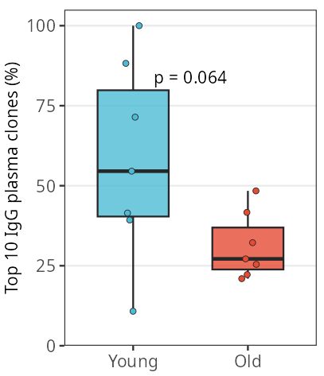

```r
if (!exists("pct1")) pct1 <- function(x) sprintf("%.2f%%", 100 * x)
if (!exists("p3")) p3 <- function(x) sprintf("%.3f", x)
if (!exists("test_row")) {
  test_row <- function(metric) {
    hit <- collect_age_tests(stat_tests)
    hit <- hit[hit$metric == metric, , drop = FALSE]
    if (!nrow(hit)) stop("Missing test: ", metric)
    hit[nrow(hit), ]
  }
}
igg_top_cells <- analysis %>%
  filter(cell_subtype == "Plasma", isotype_group == "IGHG", !is.na(clone_id))
igg_top <- donor_clone_metrics(igg_top_cells, "clone_id") %>%
  filter(n_bcr >= min_subtype_cells)
stat_tests[[length(stat_tests) + 1]] <- wilcox_age(
  igg_top, "top10_frac", "IGHG Plasma; top10_frac", "igg_plasma", min_donors
)
p_igg_top <- plot_age_box(igg_top, "top10_frac", "Top 10 IgG plasma clones (%)", NULL, percent = TRUE)
p_igg_top <- annotate_age_plot(
  p_igg_top, igg_top, "top10_frac", collect_age_tests(stat_tests),
  tibble(family = "igg_plasma", metric = "IGHG Plasma; top10_frac")
)
save_plot(p_igg_top, "28_igg_plasma_top10", 1.85, 2.15)
print(p_igg_top)
```

**查看分析代码**

```r
write_fig_xlsx("28_igg_plasma_top10", igg_top, statistics_from_plot(p_igg_top),
  tibble(field = c("sample_id", "age_group", "n_bcr", "top10_frac"),
    meaning = c("供者", "年龄组", "IgG 浆细胞数", "最大 10 个克隆占这些细胞的比例")),
  tibble(item = "min_subtype_cells", value = min_subtype_cells))
```

图 28. 每个点是一位供者。这里只看 IgG 浆细胞。纵轴是该供者最大的 10 个克隆占这些细胞的百分比。如果一位供者只有 10 个能定义克隆的 IgG 浆细胞，即使每个细胞各属一个克隆，Top 10 占比也是 100%，不能据此判断扩增更强。年轻组中位数是 54.55%，年老组是 27.14%（p = 0.064）。这不是图 13 的全库结果。

**查看分析代码**

[figure not shown]

```r
igg_v_cells <- analysis %>%
  filter(cell_subtype == "Plasma", isotype_group == "IGHG", !v_ambiguous, sample_id %in% library_donors)
igg_v_donors <- igg_v_cells %>%
  count(sample_id, name = "n_bcr") %>%
  filter(n_bcr >= min_subtype_cells) %>%
  pull(sample_id)
igg_v_cell <- v_usage_grid(igg_v_cells, igg_v_donors, weight = "cell") %>%
  left_join(sample_info %>% select(sample_id, age_group), by = "sample_id")
igg_v_mean <- igg_v_cell %>%
  group_by(v_gene) %>%
  summarise(mean_pct = mean(pct), .groups = "drop") %>%
  arrange(desc(mean_pct))
igg_v_genes <- head(igg_v_mean %>% filter(mean_pct >= 1) %>% pull(v_gene), 15)
for (gene in igg_v_genes) {
  stat_tests[[length(stat_tests) + 1]] <- wilcox_age(
    igg_v_cell %>% filter(v_gene == gene), "pct",
    paste0("Cell-weighted IGHV within IgG Plasma, ", gene),
    "igg_plasma_v", min_donors
  )
}
p_igg_v <- igg_v_cell %>%
  filter(v_gene %in% igg_v_genes) %>%
  mutate(v_gene = factor(v_gene, levels = rev(igg_v_genes))) %>%
  ggplot(aes(v_gene, pct, fill = age_group)) +
  geom_boxplot(outlier.shape = NA, width = 0.7, position = position_dodge(0.8)) +
  geom_point(position = position_jitterdodge(jitter.width = 0.1, dodge.width = 0.8), size = 1, alpha = 0.75) +
  scale_fill_manual(values = age_col) +
  coord_flip() + theme_bcr(8) +
  labs(x = NULL, y = "IgG plasma cells (%)", title = "IGHV in IgG plasma")
igg_v_annotation <- tibble(
  v_gene = factor(igg_v_genes, levels = rev(igg_v_genes)),
  family = "igg_plasma_v",
  metric = paste0("Cell-weighted IGHV within IgG Plasma, ", igg_v_genes)
) %>%
  left_join(collect_age_tests(stat_tests), by = c("family", "metric"))
stopifnot(!anyNA(igg_v_annotation$test_id))
igg_v_annotation$annotation_label <- format_exact_p(igg_v_annotation$p_value)
igg_vmax <- max(igg_v_cell$pct[igg_v_cell$v_gene %in% igg_v_genes])
igg_v_annotation$annotation_y <- igg_vmax * 1.06
p_igg_v <- p_igg_v + geom_text(
  data = igg_v_annotation, aes(x = v_gene, y = annotation_y, label = annotation_label),
  inherit.aes = FALSE, hjust = 0, size = 2.1, family = bcr_font_family, lineheight = 1
) +
  scale_y_continuous(limits = c(0, igg_vmax * 1.42), expand = expansion(mult = c(.01, .02)))
attr(p_igg_v, "bcr_stat_annotations") <- igg_v_annotation
save_plot(p_igg_v, "29_igg_plasma_ighv", 7.2, 5.2)
print(p_igg_v)
```

**查看分析代码**

```r
write_fig_xlsx("29_igg_plasma_ighv", igg_v_cell %>% filter(v_gene %in% igg_v_genes),
  statistics_from_plot(p_igg_v),
  tibble(field = c("sample_id", "age_group", "v_gene", "n", "n_total", "pct"),
    meaning = c("供者", "年龄组", "IGHV 基因", "该基因的 IgG 浆细胞数", "该供者 IgG 浆细胞数", "使用百分比")),
  tibble(item = "min_subtype_cells", value = min_subtype_cells))
write_xlsx(list(cell_weighted = igg_v_cell), "igg_plasma_v")
```

图 29. 每个点是一位供者。这里按细胞计数，看每个 IGHV 占该供者 IgG 浆细胞的百分比，也就是 IGHV 使用频率。图上是平均频率至少 1% 的前 15 个基因，基因名右侧是该项原始 p。按 igg_plasma_v 做 BH 校正后，本版没有基因低于 0.05；另外两份交付版也同样没有。它和图 10 的全库使用频率不是同一张图。

## 12 主要结论

下表是去掉 O6、O8、O11 之后的供者中位数，年轻组在前、年老组在后。只有“占 B 系细胞比例”和 Immature B 比例以全部 B 系细胞为分母。扩增比例的分母是该亚型或该比较范围内的重链细胞。IgG 占浆细胞比例的分母是有可用重链的浆细胞。图上括号是原始 p，表里另有同 family 的参考 BH。原始 p < 0.05 只记为探索性信号。完整比较见 `age_tests.xlsx`。

**浆细胞**  
图 05 看浆细胞占 B 细胞的比例：大约 5.6% 到 23.8%，10 位年轻供者和 8 位年老供者，原始 p 约 0.015。年老组更高，但这是比例，不能说骨髓里的浆细胞数量一定增加了。图 07 看浆细胞里的扩增细胞：大约 6.5% 到 12.5%，原始 p 约 0.15，还不能说扩增更强。图 11 的 V 区突变两组接近，原始 p = 0.378。浆细胞 Gini–Simpson 的原始 p = 0.0304，参考 BH = 0.1215。浆细胞 Shannon 的原始 p = 0.0265，参考 BH = 0.2912。这两项多样性都受回收到的浆细胞数影响，不能单独当成年龄效应。

**IgG 浆细胞**  
图 25 看 IgG 浆细胞内部的扩增，年老组中位数更高，但 p 大约 0.39，两组重叠很大。图 26 的 V 区突变两组都在 9% 左右，没有明确差别。图 27 看克隆是否分散；O8 本来是年老组里最低的一点，去掉之后这张图不再被这一个供者拉动。IgG 占该供者全部浆细胞的比例，年老组大约一半，年轻组大约三分之二，年老组并没有更高。这几项都还是线索，不能写成 IgG 浆细胞已经扩增或突变更高。

**记忆 B 与其他**  
Memory B 的比例、扩增和突变仍列在表里，方便和浆细胞对照。Immature B 比例下降说明早期 B 细胞的组成变了。全部 B 细胞放在一起看，扩增没有稳定的年龄差异。STARTRAC 不拿来做扩增结论。本版没有做共享克隆，也没有做抗原库比对。年轻组 4/10、年老组 8/8 来自动脉瘤相关手术。

**三份交付版怎么一起看**  
最初 21 人版里，浆细胞占 B 系细胞比例的原始 p 是 0.113。只去掉 O6 和 O11 的交付版里，这一比例的原始 p 是 0.045。本版再去掉 O8 后，该比例的 p 更小，但浆细胞扩增、浆细胞突变，以及 IgG 浆细胞的扩增和 IgG 占比，p 反而更大。浆细胞多样性的 p 也更小。三份都只描述各自队列里的观察。

**查看分析代码**

```r
summary_specs <- tibble(
  亚型 = c(
    rep("Plasma", 5), rep("IgG Plasma", 4), rep("Memory B", 4), "早期组成", "全库对照"
  ),
  family = c(
    "abundance", "expansion", "shm_cell", "diversity", "expansion",
    "igg_plasma", "igg_plasma", "shm_plasma_isotype", "igg_plasma",
    "abundance", "expansion", "shm_cell", "shm_memory_isotype",
    "abundance", "expansion"
  ),
  metric = c(
    "Subtype fraction, Plasma", "Plasma; primary; expanded_frac",
    "Cell-median SHM, Plasma", "Gini-Simpson, Plasma", "Plasma; primary; shannon",
    "IGHG fraction within Plasma", "IGHG Plasma; expanded_frac",
    "Plasma SHM within IGHG", "Gini-Simpson, IGHG Plasma",
    "Subtype fraction, Memory B", "Memory B; primary; expanded_frac",
    "Cell-median SHM, Memory B", "Memory SHM within IGHG",
    "Subtype fraction, Immature B", "All B-lineage heavy chains; primary; expanded_frac"
  ),
  label = c(
    "占 B 系细胞比例 (%)", "扩增细胞比例 (%)", "V 区突变 (%)", "Gini–Simpson", "Shannon",
    "IgG 占浆细胞比例 (%)", "扩增细胞比例 (%)", "V 区突变 (%)", "Gini–Simpson",
    "占 B 系细胞比例 (%)", "扩增细胞比例 (%)", "V 区突变 (%)", "IgG 层 V 区突变 (%)",
    "Immature B 比例 (%)", "全 B 系扩增比例 (%)"
  ),
  multiplier = c(100, 100, 1, 1, 1, 100, 100, 1, 1, 100, 100, 1, 1, 100, 100)
)
summary_table <- summary_specs %>%
  left_join(tests, by = c("family", "metric")) %>%
  transmute(
    亚型, 指标 = label, Young_n = n_young, Old_n = n_old,
    Young中位数 = median_young * multiplier, Old中位数 = median_old * multiplier,
    差值_Old减Young = median_difference_old_minus_young * multiplier,
    检验 = test_method, 原始p = p_value, 参考BH = p_bh
  )
knitr::kable(summary_table, digits = 4)
```

| 亚型 | 指标 | Young_n | Old_n | Young中位数 | Old中位数 | 差值_Old减Young | 检验 | 原始p | 参考BH |
| --- | --- | --- | --- | --- | --- | --- | --- | --- | --- |
| Plasma | 占 B 系细胞比例 (%) | 10 | 8 | 5.5450 | 23.8263 | 18.2812 | Wilcoxon | 0.0145 | 0.0436 |
| Plasma | 扩增细胞比例 (%) | 9 | 8 | 6.4516 | 12.5150 | 6.0634 | Welch t-test | 0.1473 | 0.4193 |
| Plasma | V 区突变 (%) | 9 | 8 | 9.3750 | 9.6749 | 0.2999 | Welch t-test | 0.3780 | 0.3780 |
| Plasma | Gini–Simpson | 9 | 8 | 0.9536 | 0.9860 | 0.0324 | Wilcoxon | 0.0304 | 0.1215 |
| Plasma | Shannon | 9 | 8 | 3.1707 | 4.3618 | 1.1911 | Welch t-test | 0.0265 | 0.2912 |
| IgG Plasma | IgG 占浆细胞比例 (%) | 9 | 8 | 65.1163 | 51.6381 | -13.4782 | Welch t-test | 0.1210 | 0.1513 |
| IgG Plasma | 扩增细胞比例 (%) | 7 | 7 | 7.1429 | 20.3390 | 13.1961 | Welch t-test | 0.3866 | 0.3866 |
| IgG Plasma | V 区突变 (%) | 7 | 7 | 8.9812 | 9.3806 | 0.3994 | Welch t-test | 0.2103 | 0.4207 |
| IgG Plasma | Gini–Simpson | 7 | 7 | 0.9463 | 0.9794 | 0.0331 | Welch t-test | 0.0771 | 0.1286 |
| Memory B | 占 B 系细胞比例 (%) | 10 | 8 | 12.4411 | 22.2552 | 9.8141 | Welch t-test | 0.2163 | 0.3244 |
| Memory B | 扩增细胞比例 (%) | 9 | 8 | 0.0000 | 2.7209 | 2.7209 | Wilcoxon | 0.2308 | 0.4617 |
| Memory B | V 区突变 (%) | 9 | 8 | 4.5139 | 5.7873 | 1.2734 | Welch t-test | 0.0051 | 0.0102 |
| Memory B | IgG 层 V 区突变 (%) | 8 | 5 | 6.3896 | 7.5055 | 1.1159 | Welch t-test | 0.0053 | 0.0160 |
| 早期组成 | Immature B 比例 (%) | 10 | 8 | 11.8688 | 2.7644 | -9.1044 | Wilcoxon | 0.0009 | 0.0078 |
| 全库对照 | 全 B 系扩增比例 (%) | 9 | 8 | 4.6632 | 8.1764 | 3.5132 | Wilcoxon | 0.1124 | 0.4045 |

## 附录：结果文件

下面保存细胞表和 Seurat 对象，用来核对，不是给阅读结论用的。每个供者的每个克隆只占一行。

**查看分析代码**

```r
top_clones <- analysis %>%
  filter(!is.na(clone_id)) %>%
  group_by(sample_id, clone_id) %>%
  summarise(
    age_group = first(age_group),
    clone_size = first(clone_size),
    v_gene = first(v_gene),
    j_gene = first(j_gene),
    cdr3_aa = first(cdr3_aa),
    subtypes = paste(sort(unique(as.character(cell_subtype))), collapse = ";"),
    isotypes = paste(sort(unique(na.omit(c_gene))), collapse = ";"),
    .groups = "drop"
  ) %>%
  group_by(sample_id) %>%
  arrange(desc(clone_size), clone_id, .by_group = TRUE) %>%
  slice_head(n = 15) %>%
  ungroup()
stopifnot(!anyDuplicated(top_clones[c("sample_id", "clone_id")]))

idx <- match(analysis$barcode, colnames(obj))
stopifnot(!anyNA(idx))
metadata_fields <- c(
  "contig_id", "v_gene", "j_gene", "c_gene", "isotype", "isotype_group", "switched",
  "clone_id", "clone_id_vj_nt", "clone_id_paired", "clone_size", "subtype_clone_size",
  "isotype_clone_size", "expanded_repertoire", "expanded_within_subtype", "expanded_within_isotype",
  "n_productive_igh", "n_rearrangements", "v_ambiguous", "v_orphon", "paired_light",
  "mu_percent", "shm_reason"
)
for (field in metadata_fields) {
  values <- analysis[[field]]
  if (is.factor(values)) values <- as.character(values)
  aligned <- values[rep(NA_integer_, ncol(obj))]
  aligned[idx] <- values
  obj[[field]] <- aligned
}
check <- tibble(
  barcode = analysis$barcode,
  c_obj = obj$c_gene[idx],
  c_tab = analysis$c_gene,
  clone_obj = obj$clone_size[idx],
  clone_tab = analysis$clone_size,
  mu_obj = obj$mu_percent[idx],
  mu_tab = analysis$mu_percent
)
stopifnot(
  all(check$c_obj == check$c_tab | (is.na(check$c_obj) & is.na(check$c_tab))),
  all(check$clone_obj == check$clone_tab | (is.na(check$clone_obj) & is.na(check$clone_tab))),
  all(abs(check$mu_obj - check$mu_tab) < 1e-8 | (is.na(check$mu_obj) & is.na(check$mu_tab)))
)

saveRDS(analysis, file.path(rdata_dir, "bcr_cells.rds"))
saveRDS(obj, file.path(rdata_dir, "b_lineage_with_bcr.rds"))
write_xlsx(analysis %>% select(
  barcode, sample_id, age_group, sex, aneurysm, cluster, cell_subtype, lineage,
  contig_id, v_gene, d_gene, j_gene, c_gene, isotype, isotype_group, switched, v_orphon, v_ambiguous,
  cdr3_aa, cdr3_nt, reads, umis, n_productive_igh, n_rearrangements,
  light_contig_id, light_v, light_j, light_c, light_cdr3_aa,
  clone_id, clone_id_vj_nt, clone_id_paired, clone_size, subtype_clone_size, isotype_clone_size,
  expanded_repertoire, expanded_within_subtype, expanded_within_isotype,
  mu_percent, v_identity, callable_v_bases, shm_reason
), "bcr_cells")
write_xlsx(top_clones, "top_clones")

tests %>%
  filter(family %in% c("abundance", "expansion", "isotype", "shm_cell", "shm_memory_isotype")) %>%
  select(family, metric, n_young, n_old, median_young, median_old, test_method,
    shapiro_young_p, shapiro_old_p, p_value, note) %>%
  arrange(family, p_value)
```

| family | metric | n_young | n_old | median_young | median_old | test_method | shapiro_young_p | shapiro_old_p | p_value | note |
| --- | --- | --- | --- | --- | --- | --- | --- | --- | --- | --- |
| abundance | Subtype fraction, Immature B | 10 | 8 | 0.11868837 | 0.027644458 | Wilcoxon | 1.901147e-04 | 5.445142e-01 | 0.0008623589 |  |
| abundance | Subtype fraction, Transitional B | 10 | 8 | 0.09793867 | 0.042084266 | Welch t-test | 5.708192e-01 | 6.274359e-01 | 0.0108539054 |  |
| abundance | Subtype fraction, Plasma | 10 | 8 | 0.05545042 | 0.238262915 | Wilcoxon | 5.463707e-03 | 1.649204e-01 | 0.0145480239 |  |
| abundance | Subtype fraction, Pro-B | 10 | 8 | 0.01675678 | 0.027930432 | Welch t-test | 2.052475e-01 | 7.377257e-01 | 0.0847871089 |  |
| abundance | Subtype fraction, Small Pre-B | 10 | 8 | 0.15283418 | 0.088210368 | Welch t-test | 6.828914e-01 | 3.288803e-01 | 0.1457135146 |  |
| abundance | Subtype fraction, Memory B | 10 | 8 | 0.12441115 | 0.222551787 | Welch t-test | 1.440748e-01 | 7.128755e-02 | 0.2162657343 |  |
| abundance | Subtype fraction, Large Pre-B | 10 | 8 | 0.07084404 | 0.063930482 | Welch t-test | 1.652859e-01 | 5.138583e-01 | 0.4554404096 |  |
| abundance | Subtype fraction, Cycling precursor | 10 | 8 | 0.02076585 | 0.020460251 | Wilcoxon | 2.900040e-04 | 1.418488e-02 | 0.6250627252 |  |
| abundance | Subtype fraction, Naive B | 10 | 8 | 0.14732669 | 0.154501976 | Welch t-test | 1.170675e-01 | 5.117702e-02 | 0.9458550991 |  |
| expansion | Plasma; primary; shannon | 9 | 8 | 3.17073311 | 4.361828147 | Welch t-test | 6.671983e-01 | 3.898872e-01 | 0.0264647807 |  |

[output cut: 60 more lines]

## 13 克隆、同种型和突变的其余图

这些图补充前面的主结果。每个点仍然是一位供者。Shannon 会随着采到的细胞数变大，细胞多的供者数值自然更高，所以不能把它的年龄差异解释成克隆多样性变了。

**查看分析代码**

```r
dict_donor <- tibble(
  field = c("sample_id", "age_group", "fraction", "expanded_frac", "median_mu", "pct"),
  meaning = c("供者", "年龄组", "占该供者 B 系细胞的比例", "扩增细胞占该层能定义克隆的细胞的比例",
              "V 区突变频率中位数，百分数", "V 基因使用率，百分数；未观察到为 0")
)
params <- tibble(item = c("min_bcr_cells", "min_subtype_cells", "min_donors", "normality_alpha"),
                 value = c(min_bcr_cells, min_subtype_cells, min_donors, normality_alpha))
stat_for <- function(ids) tests %>% filter(test_id %in% ids)

save_plot(p_frac, "05_subtype_fraction_by_age", 5.2, 2.2)
write_fig_xlsx("05_subtype_fraction", subtype_grid %>% filter(cell_subtype %in% fraction_main),
  statistics_from_plot(p_frac), dict_donor, params)
save_plot(p_frac_rest, "05s_subtype_fraction_other", 5.3, 4.3)
write_fig_xlsx("05s_subtype_fraction", subtype_grid %>% filter(cell_subtype %in% fraction_rest),
  statistics_from_plot(p_frac_rest), dict_donor, params)

save_plot(p_exp, "06_expanded_fraction_all", 1.85, 2.15)
write_fig_xlsx("06_expanded_all", p_exp$data,
  statistics_from_plot(p_exp), dict_donor, params)

save_plot(p_exp_sub, "07_expanded_fraction_by_subtype", 5.2, 2.2)
write_fig_xlsx("07_expanded_subtype", subtype_summary %>% filter(cell_subtype %in% main_subtypes),
  statistics_from_plot(p_exp_sub), dict_donor, params)
save_plot(p_exp_rest, "07s_expanded_other_subtypes", 5.3, 4.3)
write_fig_xlsx("07s_expanded_subtype", subtype_summary %>% filter(cell_subtype %in% other_subtypes),
  statistics_from_plot(p_exp_rest), dict_donor, params)
```

**查看分析代码**

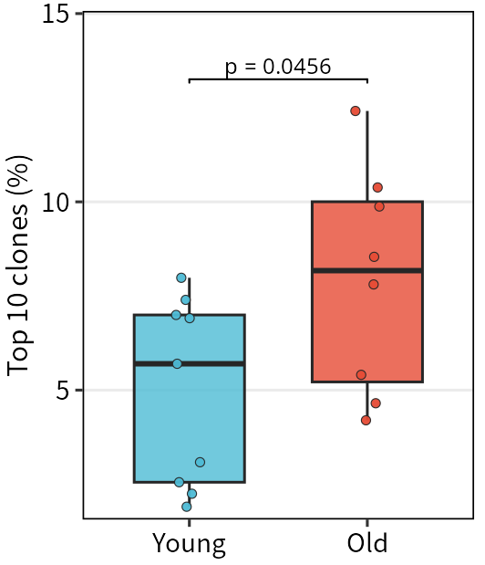

```r
p_top <- plot_age_box(
  primary %>% filter(compartment == "All B-lineage heavy chains", n_bcr >= min_bcr_cells),
  "top10_frac", "Top 10 clones (%)", NULL, percent = TRUE
)
p_top <- annotate_age_plot(p_top,
  primary %>% filter(compartment == "All B-lineage heavy chains", n_bcr >= min_bcr_cells),
  "top10_frac", tests, tibble(family = "expansion", metric = "All B-lineage heavy chains; primary; top10_frac"))
save_plot(p_top, "13_top10_fraction", 1.85, 2.15)
print(p_top)
```

**查看分析代码**

```r
write_fig_xlsx("13_top10", p_top$data,
  statistics_from_plot(p_top), dict_donor, params)
```

图 13. 每个点是一位供者；范围是**全部 B 系重链**，不是单独 Plasma。纵轴为最大 10 个克隆占该供者重链细胞的百分比，属描述性指标，不作浆细胞集中度的年龄结论。

**查看分析代码**

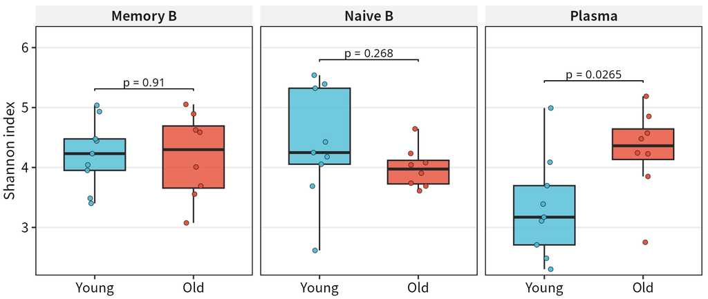

```r
p_shan <- plot_age_box(
  primary %>% filter(compartment %in% c("Naive B", "Memory B", "Plasma"), n_bcr >= min_subtype_cells),
  "shannon", "Shannon index", NULL, "compartment"
)
p_shan <- annotate_age_plot(p_shan,
  primary %>% filter(compartment %in% main_subtypes, n_bcr >= min_subtype_cells), "shannon", tests,
  tibble(compartment = main_subtypes, family = "expansion", metric = paste(main_subtypes, "primary", "shannon", sep = "; ")),
  facets = "compartment")
save_plot(p_shan, "14_shannon_main_subtypes", 5.2, 2.2)
print(p_shan)
```

**查看分析代码**

```r
write_fig_xlsx("14_shannon", p_shan$data,
  statistics_from_plot(p_shan), dict_donor, params)
```

图 14. 每个点是一位供者，分面为 Naive B、Memory B、Plasma。纵轴为 Shannon 指数，随回收细胞数增大而倾向升高。Plasma 这一格尤其受每位供者回收到多少浆细胞的影响，要和图 03 的回收情况一起看，不宜单独当成年龄效应。Memory B 的 Shannon 原始 p = 0.910，没有稳定的组间差异。

**查看分析代码**

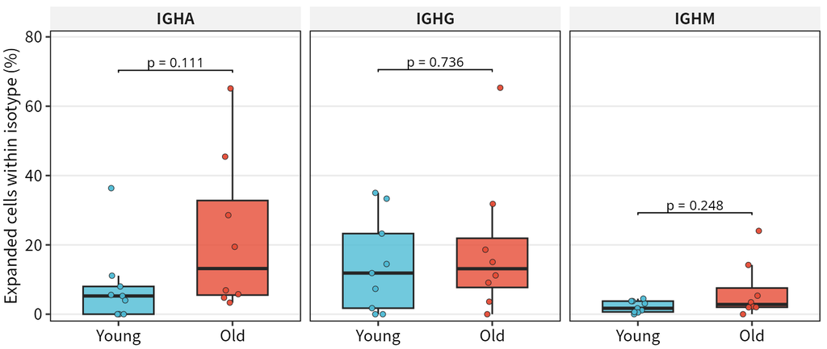

```r
p_iso_exp <- plot_age_box(iso_exp %>% filter(isotype_group %in% c("IGHM", "IGHG", "IGHA")), "expanded_within_isotype", "Expanded cells within isotype (%)", NULL, "isotype_group", percent = TRUE)
p_iso_exp <- annotate_age_plot(p_iso_exp, iso_exp %>% filter(isotype_group %in% c("IGHM", "IGHG", "IGHA")),
  "expanded_within_isotype", tests,
  tibble(isotype_group = c("IGHM", "IGHG", "IGHA"), family = "isotype",
    metric = paste0("Within-isotype expanded fraction, ", c("IGHM", "IGHG", "IGHA"))), facets = "isotype_group")
save_plot(p_iso_exp, "16_expansion_within_isotype", 5.2, 2.2)
print(p_iso_exp)
```

**查看分析代码**

```r
write_fig_xlsx("16_within_isotype", p_iso_exp$data, statistics_from_plot(p_iso_exp), dict_donor, params)
```

图 16. 每个点是一位供者，分面是 IgM、IgG、IgA。纵轴是这一类抗体内部的扩增细胞百分比。同一个克隆如果一个细胞是 IgM、另一个是 IgG，两边都不算这一类内部的扩增。

**查看分析代码**

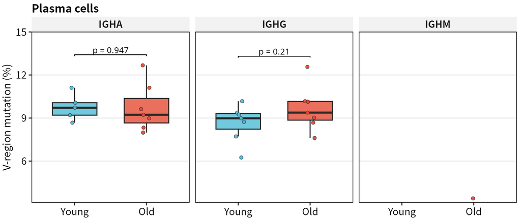

```r
p_plasma <- plot_age_box(plasma_iso %>% filter(isotype_group %in% c("IGHM", "IGHG", "IGHA")), "median_mu", "V-region mutation (%)", "Plasma cells", "isotype_group")
p_plasma <- annotate_age_plot(p_plasma, plasma_iso %>% filter(isotype_group %in% c("IGHM", "IGHG", "IGHA")),
  "median_mu", tests, tibble(isotype_group = c("IGHM", "IGHG", "IGHA"), family = "shm_plasma_isotype",
    metric = paste0("Plasma SHM within ", c("IGHM", "IGHG", "IGHA"))), facets = "isotype_group")
save_plot(p_plasma, "17_shm_plasma_by_isotype", 5.2, 2.2)
print(p_plasma)
```

**查看分析代码**

```r
write_fig_xlsx("17_plasma_shm", p_plasma$data, statistics_from_plot(p_plasma), dict_donor, params)
```

图 17. 每个点是一位供者。这是 Plasma 再按 IgM、IgG、IgA 看的 V 区突变中位数。IgM Plasma 多数供者不到 10 个细胞，所以不检验；缺的组不是这个年龄没有 IgM Plasma。

**查看分析代码**

```r
umap_b <- emb %>%
  left_join(analysis %>% select(barcode, isotype_group, clone_size, mu_percent), by = "barcode") %>%
  mutate(
    isotype_panel = factor(replace_na(as.character(isotype_group), "Unknown"),
      levels = c("IGHM", "IGHD", "IGHG", "IGHA", "IGHE", "Unknown")),
    clone_panel = case_when(
      lineage == "Non-B" ~ "Non-B",
      is.na(clone_size) ~ "No heavy chain",
      clone_size <= 1 ~ "Single",
      TRUE ~ "Expanded"
    )
  )
p_age <- ggplot(umap_b %>% filter(lineage != "Non-B"), aes(UMAP_1, UMAP_2, color = age_group)) +
  geom_point(size = 0.4, alpha = 0.35) +
  scale_color_manual(values = age_col) +
  coord_fixed(xlim = umap_limits$x, ylim = umap_limits$y) +
  theme_umap_ref() + labs(title = "Age group", x = "UMAP-1", y = "UMAP-2")
p_clone <- ggplot(umap_b %>% filter(lineage != "Non-B"), aes(UMAP_1, UMAP_2, color = clone_panel)) +
  geom_point(size = 0.4, alpha = 0.35) +
  coord_fixed(xlim = umap_limits$x, ylim = umap_limits$y) +
  theme_umap_ref() + labs(title = "Clone size", x = "UMAP-1", y = "UMAP-2")
p_iso_u <- ggplot(umap_b %>% filter(lineage != "Non-B"), aes(UMAP_1, UMAP_2, color = isotype_panel)) +
  geom_point(size = 0.4, alpha = 0.35) +
  scale_color_manual(values = c(isotype_group_col, Unknown = "grey80")) +
  coord_fixed(xlim = umap_limits$x, ylim = umap_limits$y) +
  theme_umap_ref() + labs(title = "Isotype", x = "UMAP-1", y = "UMAP-2")
p_mu <- ggplot(umap_b %>% filter(lineage != "Non-B"), aes(UMAP_1, UMAP_2, color = mu_percent)) +
  geom_point(size = 0.4, alpha = 0.35) +
  scale_color_viridis_c(option = "magma", na.value = "grey85") +
  coord_fixed(xlim = umap_limits$x, ylim = umap_limits$y) +
  theme_umap_ref() + labs(title = "V-region mutation (%)", x = "UMAP-1", y = "UMAP-2", color = NULL)
p_clone <- p_clone + scale_color_manual(values = c("No heavy chain" = "grey82", Single = "#4DBBD5", Expanded = "#E64B35"))
with_fixed_legend <- function(p) {
  leg <- cowplot::get_plot_component(
    p + theme(legend.position = "bottom", legend.text = element_text(size = 10)) +
      guides(color = guide_legend(nrow = 1)), "^guide-box-bottom$")
  stopifnot(inherits(leg, "gtable"))
  cowplot::plot_grid(p + theme(legend.position = "none"), leg, ncol = 1, rel_heights = c(1, .14))
}
p_mu_leg <- cowplot::get_plot_component(p_mu + theme(legend.position = "bottom") +
  guides(color = guide_colorbar(direction = "horizontal", barwidth = unit(3, "cm"))), "^guide-box-bottom$")
stopifnot(inherits(p_mu_leg, "gtable"))
p_mu_panel <- cowplot::plot_grid(p_mu + theme(legend.position = "none"), p_mu_leg, ncol = 1, rel_heights = c(1, .14))
p_umap_panels <- plot_grid(with_fixed_legend(p_age), with_fixed_legend(p_clone),
  with_fixed_legend(p_iso_u), p_mu_panel, ncol = 2) +
  theme(plot.background = element_rect(fill = "white", colour = NA))
umap_panel_data <- umap_b %>% filter(lineage != "Non-B") %>%
  select(barcode, UMAP_1, UMAP_2, age_group, cell_subtype, isotype_panel, clone_panel, mu_percent)
umap_dict <- tibble(field = c("UMAP_1", "UMAP_2", "age_group", "clone_panel", "isotype_panel", "mu_percent"),
  meaning = c("原有坐标", "原有坐标", "年龄组", "全库克隆大小", "重链类别", "V 区突变百分数"))
save_umap_panel <- function(p, name, discrete = TRUE) {
  p <- p + theme(legend.position = "bottom", legend.text = element_text(size = 7),
    axis.title = element_text(size = 7.5), plot.title = element_text(size = 8, face = "bold"))
  if (discrete) {
    p <- p + guides(color = guide_legend(override.aes = list(size = 3.2, alpha = 1)))
  }
  save_plot(p, name, 4.6, 5.1)
  invisible(p)
}
p_age_show <- save_umap_panel(p_age, "02b_umap_age")
p_clone_show <- save_umap_panel(p_clone, "02b_umap_clone")
p_iso_show <- save_umap_panel(p_iso_u, "02b_umap_isotype")
p_mu_show <- save_umap_panel(p_mu, "02b_umap_shm", discrete = FALSE)
write_fig_xlsx("02b_umap_age", umap_panel_data, NULL, umap_dict, params)
write_fig_xlsx("02b_umap_clone", umap_panel_data, NULL, umap_dict, params)
write_fig_xlsx("02b_umap_isotype", umap_panel_data, NULL, umap_dict, params)
write_fig_xlsx("02b_umap_shm", umap_panel_data, NULL, umap_dict, params)

annotated_plot_objects <- list(
  `05` = p_frac, `05s` = p_frac_rest, `06` = p_exp, `07` = p_exp_sub, `07s` = p_exp_rest,
  `09` = p_sw, `10` = p_v, `11` = p_shm, `12` = p_mem, `13` = p_top, `14` = p_shan,
  `16` = p_iso_exp, `17` = p_plasma, `22` = p_gini, `23` = p_expa, `24` = p_tran,
  `25` = p_igg_exp, `26` = p_igg_shm, `27` = p_igg_gini,
  `28` = p_igg_top, `29` = p_igg_v
)
figure_annotations <- bind_rows(lapply(names(annotated_plot_objects), function(id) {
  statistics_from_plot(annotated_plot_objects[[id]]) %>% mutate(figure_id = id)
}))
if ("p_bh" %in% names(figure_annotations)) {
  figure_annotations <- figure_annotations %>% select(-p_bh)
}
figure_annotations <- figure_annotations %>%
  left_join(tests %>% select(test_id, p_bh), by = "test_id")
annotation_check <- figure_annotations %>% left_join(tests %>% select(test_id, final_p = p_value), by = "test_id")
stopifnot(all(abs(annotation_check$p_value - annotation_check$final_p) < 1e-12, na.rm = TRUE))
write_csv(figure_annotations, file.path(tab_dir, "figure_stat_annotations.csv"), na = "")
umap_plot_objects <- list(subtype = p_umap, age = p_age, clone = p_clone, isotype = p_iso_u, shm = p_mu)
umap_display_audit <- bind_rows(lapply(names(umap_plot_objects), function(panel) {
  p <- umap_plot_objects[[panel]]
  pp <- ggplot_build(p)$layout$panel_params[[1]]
  tibble(panel = panel, x_min = pp$x.range[1], x_max = pp$x.range[2],
    y_min = pp$y.range[1], y_max = pp$y.range[2], coordinate_ratio = p$coordinates$ratio,
    point_shape = as.numeric(ggplot2::GeomPoint$default_aes$shape),
    font = bcr_font_family)
}))
write_csv(umap_display_audit, file.path(tab_dir, "umap_display_audit.csv"))

figure_index <- tibble(
  figure_id = c("01", "02", "02b", "02c", "02d", "02e", "03", "04", "05", "05s", "06", "07", "07s",
    "08", "09", "10", "11", "12", "13", "14", "16", "17", "18", "19", "20", "21", "22", "23", "24",
    "25", "26", "27", "28", "29"),
  title = c("Marker 点图", "亚型 UMAP", "UMAP 年龄", "UMAP 克隆大小", "UMAP 同种型", "UMAP 突变",
            "重链回收率", "亚型组成", "重点亚型比例", "其余亚型比例", "全库扩增", "主要亚型内扩增", "其余亚型内扩增",
            "同种型构成", "类别转换", "IGHV 使用率", "主要亚型 SHM", "Memory B 分同种型 SHM",
            "Top 10 克隆占比", "Shannon", "同种型内扩增", "Plasma 分同种型 SHM",
            "供者克隆大小", "年轻年老克隆大小", "亚型克隆大小甜甜圈", "扩增细胞亚型甜甜圈",
            "Gini-Simpson", "STARTRAC 扩增", "STARTRAC 亚型间共享",
            "IgG 浆细胞扩增", "IgG 浆细胞 SHM", "IgG 浆细胞 Gini",
            "IgG 浆细胞 Top 10", "IgG 浆细胞 IGHV"),
  workbook = paste0("fig_", c(
    "01_markers", "02_umap", "02b_umap_age", "02b_umap_clone", "02b_umap_isotype", "02b_umap_shm",
    "03_recovery", "04_composition", "05_subtype_fraction", "05s_subtype_fraction",
    "06_expanded_all", "07_expanded_subtype", "07s_expanded_subtype", "08_isotype_stack", "09_switched",
    "10_ighv", "11_shm_main", "12_memory_shm", "13_top10", "14_shannon",
    "16_within_isotype", "17_plasma_shm", "18_clone_size_by_donor", "19_clone_homeostasis",
    "20_clone_size_donuts", "21_expanded_subtype_donuts", "22_gini",
    "23_startrac_expansion", "23_startrac_transition",
    "25_igg_plasma_expanded", "26_igg_plasma_shm", "27_igg_plasma_gini",
    "28_igg_plasma_top10", "29_igg_plasma_ighv"), ".xlsx"),
  unit = "见 dictionary sheet"
)
figure_stem <- c(
  "01_marker_dotplot", "02_umap_subtype", "02b_umap_age", "02b_umap_clone", "02b_umap_isotype", "02b_umap_shm",
  "03_b_lineage_recovery", "04_subtype_composition", "05_subtype_fraction_by_age", "05s_subtype_fraction_other",
  "06_expanded_fraction_all", "07_expanded_fraction_by_subtype", "07s_expanded_other_subtypes",
  "08_isotype_by_subtype", "09_switched_by_main_subtype", "10_ighv_usage", "11_shm_main_subtypes",
  "12_shm_memory_by_isotype", "13_top10_fraction", "14_shannon_main_subtypes", "16_expansion_within_isotype",
  "17_shm_plasma_by_isotype", "18_clone_size_by_donor", "19_clone_homeostasis", "20_clone_size_donuts",
  "21_expanded_subtype_donuts", "22_gini_simpson", "23_startrac_expansion", "23_startrac_transition",
  "25_igg_plasma_expanded", "26_igg_plasma_shm", "27_igg_plasma_gini",
  "28_igg_plasma_top10", "29_igg_plasma_ighv"
)
stopifnot(length(figure_stem) == nrow(figure_index))
figure_index <- figure_index %>%
  mutate(pdf = paste0(figure_stem, ".pdf"), png = paste0(figure_stem, ".png"))
write_xlsx(figure_index, "figure_table_map")
write_csv(figure_index, file.path(tab_dir, "figure_table_map.csv"))
```

**查看分析代码**

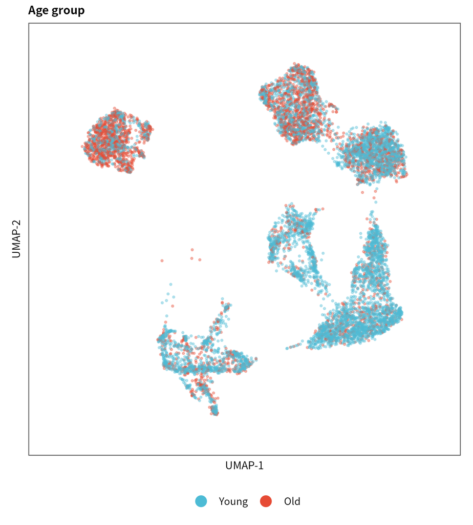

```r
print(p_age_show)
```

图 02b. 颜色是年龄组。

**查看分析代码**

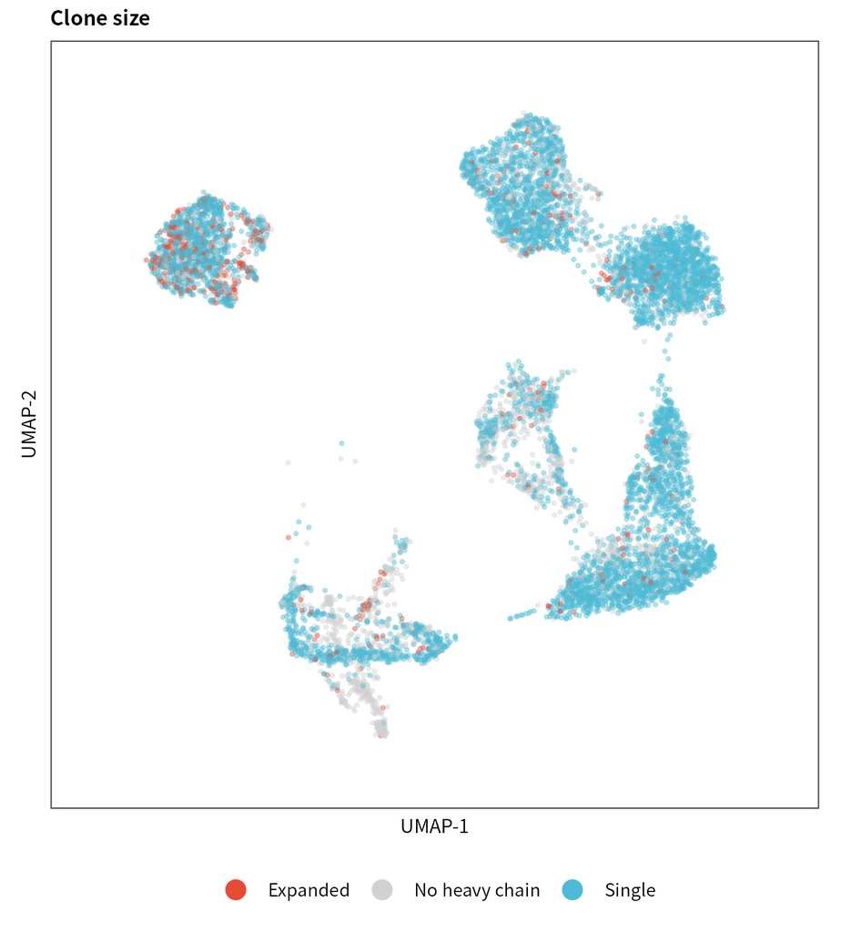

```r
print(p_clone_show)
```

图 02c. 颜色是克隆大小。灰色是没有可用重链。